# Capstone Project: Predictive Maintenance for Turbofan Engines

## Prognostics and Health Management (PHM) using Deep Learning

### 1. Details of Dataset & Business Problem

**Reference Link:** [NASA C-MAPSS Jet Engine Simulated Data](https://data.nasa.gov/dataset/cmapss-jet-engine-simulated-data)

### Group 5: Karthik Kunnamkumarath, Aswin Anil Bindu, Sreelakshmi Nair, Tuna Güzelmeriç, Cindy Mai

#### Business Problem Description

In the aerospace and heavy machinery industries, **unscheduled maintenance** accounts for a significant portion of operational costs and fleet downtime. Traditional "preventive" maintenance (replacing parts on a fixed schedule) is inefficient because parts are often replaced while they still have useful life.

**Objective:** This project aims to develop a **Prognostics and Health Management (PHM)** system. By analyzing sensor data (temperature, pressure, fan speeds) from the NASA C-MAPSS dataset, we will predict the **Remaining Useful Life (RUL)** of turbofan engines.

**Value Proposition:** A highly accurate RUL prediction model enables **Predictive Maintenance**, allowing operators to:

1. **Reduce Costs:** Maximize part usage before replacement.
2. **Improve Safety:** Detect potential failures before they become catastrophic.
3. **Optimize Logistics:** Schedule repairs only when necessary (Just-in-Time maintenance).

#### Dataset Overview (FD001)

We are using the **FD001** subset of the C-MAPSS data, which simulates:

- **Asset:** High-bypass turbofan engine.
- **Conditions:** Sea-level operations (constant).
- **Fault Mode:** High-Pressure Compressor (HPC) degradation.
- **Train/Test Split:** * `Train`: Run-to-failure (engines run until they break).
  - `Test`: Run-to-prior-failure (engines stop at a random point; we must predict when they *would* have failed).

```python
import pandas as pd
import numpy as np
import matplotlib.pyplot as plt
import seaborn as sns
import os
import random

# === GLOBAL SEEDS FOR REPRODUCIBILITY ===
# Setting these once at the top ensures identical results on every run
SEED = 42
random.seed(SEED)
np.random.seed(SEED)

# TensorFlow seed is set after import in the model cell
# Professional plotting style
plt.style.use('ggplot')
sns.set_palette("tab10")
plt.rcParams['figure.figsize'] = (12, 6)

print("Libraries imported successfully. Random seed set to 42.")
```

```
Libraries imported successfully. Random seed set to 42.
```

```python
# Define column names based on NASA documentation
index_names = ['unit_number', 'time_cycles']
setting_names = ['setting_1', 'setting_2', 'setting_3']
sensor_names = ['s_{}'.format(i+1) for i in range(21)]
col_names = index_names + setting_names + sensor_names

# Load the Training Data (FD001)
# Note: Ensure 'train_FD001.txt' is in the same folder as this notebook
try:
    train_df = pd.read_csv('train_FD001.txt', sep='\s+', header=None, names=col_names)
    print(f"Training Data Loaded: {train_df.shape[0]} rows, {train_df.shape[1]} columns")
except FileNotFoundError:
    print("Error: 'train_FD001.txt' not found. Please upload the dataset to the notebook directory.")

# Load the Test Data (FD001)
try:
    test_df = pd.read_csv('test_FD001.txt', sep='\s+', header=None, names=col_names)
    print(f"Test Data Loaded: {test_df.shape[0]} rows, {test_df.shape[1]} columns")
except FileNotFoundError:
    print("Error: 'test_FD001.txt' not found.")

# Load the True RUL for Test Data (Ground Truth)
try:
    rul_df = pd.read_csv('RUL_FD001.txt', sep='\s+', header=None, names=['RUL'])
    print(f"Ground Truth RUL Loaded: {rul_df.shape[0]} rows")
except FileNotFoundError:
    print("Error: 'RUL_FD001.txt' not found.")
```

```
Training Data Loaded: 20631 rows, 26 columns
Test Data Loaded: 13096 rows, 26 columns
Ground Truth RUL Loaded: 100 rows
```

```python
# Display first 5 rows to check structure
display(train_df.head())

# Check for missing values (Sanity Check)
print("\nMissing Values Check:")
print(train_df.isnull().sum().sum())  # Should be 0

# Basic statistics to see the scale of sensors
display(train_df.describe())
```

|  | unit_number | time_cycles | setting_1 | setting_2 | setting_3 | s_1 | s_2 | s_3 | s_4 | s_5 | ... | s_12 | s_13 | s_14 | s_15 | s_16 | s_17 | s_18 | s_19 | s_20 | s_21 |
| --- | --- | --- | --- | --- | --- | --- | --- | --- | --- | --- | --- | --- | --- | --- | --- | --- | --- | --- | --- | --- | --- |
| 0 | 1 | 1 | -0.0007 | -0.0004 | 100.0 | 518.67 | 641.82 | 1589.70 | 1400.60 | 14.62 | ... | 521.66 | 2388.02 | 8138.62 | 8.4195 | 0.03 | 392 | 2388 | 100.0 | 39.06 | 23.4190 |
| 1 | 1 | 2 | 0.0019 | -0.0003 | 100.0 | 518.67 | 642.15 | 1591.82 | 1403.14 | 14.62 | ... | 522.28 | 2388.07 | 8131.49 | 8.4318 | 0.03 | 392 | 2388 | 100.0 | 39.00 | 23.4236 |
| 2 | 1 | 3 | -0.0043 | 0.0003 | 100.0 | 518.67 | 642.35 | 1587.99 | 1404.20 | 14.62 | ... | 522.42 | 2388.03 | 8133.23 | 8.4178 | 0.03 | 390 | 2388 | 100.0 | 38.95 | 23.3442 |
| 3 | 1 | 4 | 0.0007 | 0.0000 | 100.0 | 518.67 | 642.35 | 1582.79 | 1401.87 | 14.62 | ... | 522.86 | 2388.08 | 8133.83 | 8.3682 | 0.03 | 392 | 2388 | 100.0 | 38.88 | 23.3739 |
| 4 | 1 | 5 | -0.0019 | -0.0002 | 100.0 | 518.67 | 642.37 | 1582.85 | 1406.22 | 14.62 | ... | 522.19 | 2388.04 | 8133.80 | 8.4294 | 0.03 | 393 | 2388 | 100.0 | 38.90 | 23.4044 |

5 rows × 26 columns

```
Missing Values Check:
0
```

|  | unit_number | time_cycles | setting_1 | setting_2 | setting_3 | s_1 | s_2 | s_3 | s_4 | s_5 | ... | s_12 | s_13 | s_14 | s_15 | s_16 | s_17 | s_18 | s_19 | s_20 | s_21 |
| --- | --- | --- | --- | --- | --- | --- | --- | --- | --- | --- | --- | --- | --- | --- | --- | --- | --- | --- | --- | --- | --- |
| count | 20631.000000 | 20631.000000 | 20631.000000 | 20631.000000 | 20631.0 | 20631.00 | 20631.000000 | 20631.000000 | 20631.000000 | 2.063100e+04 | ... | 20631.000000 | 20631.000000 | 20631.000000 | 20631.000000 | 2.063100e+04 | 20631.000000 | 20631.0 | 20631.0 | 20631.000000 | 20631.000000 |
| mean | 51.506568 | 108.807862 | -0.000009 | 0.000002 | 100.0 | 518.67 | 642.680934 | 1590.523119 | 1408.933782 | 1.462000e+01 | ... | 521.413470 | 2388.096152 | 8143.752722 | 8.442146 | 3.000000e-02 | 393.210654 | 2388.0 | 100.0 | 38.816271 | 23.289705 |
| std | 29.227633 | 68.880990 | 0.002187 | 0.000293 | 0.0 | 0.00 | 0.500053 | 6.131150 | 9.000605 | 1.776400e-15 | ... | 0.737553 | 0.071919 | 19.076176 | 0.037505 | 1.387812e-17 | 1.548763 | 0.0 | 0.0 | 0.180746 | 0.108251 |
| min | 1.000000 | 1.000000 | -0.008700 | -0.000600 | 100.0 | 518.67 | 641.210000 | 1571.040000 | 1382.250000 | 1.462000e+01 | ... | 518.690000 | 2387.880000 | 8099.940000 | 8.324900 | 3.000000e-02 | 388.000000 | 2388.0 | 100.0 | 38.140000 | 22.894200 |
| 25% | 26.000000 | 52.000000 | -0.001500 | -0.000200 | 100.0 | 518.67 | 642.325000 | 1586.260000 | 1402.360000 | 1.462000e+01 | ... | 520.960000 | 2388.040000 | 8133.245000 | 8.414900 | 3.000000e-02 | 392.000000 | 2388.0 | 100.0 | 38.700000 | 23.221800 |
| 50% | 52.000000 | 104.000000 | 0.000000 | 0.000000 | 100.0 | 518.67 | 642.640000 | 1590.100000 | 1408.040000 | 1.462000e+01 | ... | 521.480000 | 2388.090000 | 8140.540000 | 8.438900 | 3.000000e-02 | 393.000000 | 2388.0 | 100.0 | 38.830000 | 23.297900 |
| 75% | 77.000000 | 156.000000 | 0.001500 | 0.000300 | 100.0 | 518.67 | 643.000000 | 1594.380000 | 1414.555000 | 1.462000e+01 | ... | 521.950000 | 2388.140000 | 8148.310000 | 8.465600 | 3.000000e-02 | 394.000000 | 2388.0 | 100.0 | 38.950000 | 23.366800 |
| max | 100.000000 | 362.000000 | 0.008700 | 0.000600 | 100.0 | 518.67 | 644.530000 | 1616.910000 | 1441.490000 | 1.462000e+01 | ... | 523.380000 | 2388.560000 | 8293.720000 | 8.584800 | 3.000000e-02 | 400.000000 | 2388.0 | 100.0 | 39.430000 | 23.618400 |

8 rows × 26 columns

### 2. Data Analysis & Feature Engineering

**Goal:** Transform the raw time-series data into a format suitable for supervised learning.

**Step 2.1: Generate Target Variable (RUL)** Since this is a supervised learning problem, we need a target label. For the training set, we have the full history of the engine until failure.

- **RUL Calculation:** $RUL = MaxCycle - CurrentCycle$
- **Interpretation:** When the engine starts (Cycle 1), RUL is high. At the last record, RUL is 0 (failure).

```python
def add_rul(df):
    # Get the total number of cycles for each unit
    max_cycle = df.groupby('unit_number')['time_cycles'].max().reset_index()
    max_cycle.columns = ['unit_number', 'max_cycle']

    # Merge back to the original dataframe
    df = df.merge(max_cycle, on='unit_number', how='left')

    # Calculate RUL
    df['RUL'] = df['max_cycle'] - df['time_cycles']

    # CLIP RUL at 125 cycles (standard practice for C-MAPSS)
    # Reason: Early in an engine's life, the exact RUL (e.g. 300 vs 250) is irrelevant
    # because no degradation has started. Clipping focuses the model on the
    # active degradation phase and dramatically stabilizes training.
    df['RUL'] = df['RUL'].clip(upper=125)

    # Drop the 'max_cycle' helper column as we don't need it anymore
    df.drop('max_cycle', axis=1, inplace=True)
    return df

train_df = add_rul(train_df)

# Check the new column
print("RUL Column Added (clipped at 125). Sample data:")
print(f"Max RUL: {train_df['RUL'].max()}, Min RUL: {train_df['RUL'].min()}")
display(train_df[['unit_number', 'time_cycles', 'RUL']].head())
```

```
RUL Column Added (clipped at 125). Sample data:
Max RUL: 125, Min RUL: 0
```

|  | unit_number | time_cycles | RUL |
| --- | --- | --- | --- |
| 0 | 1 | 1 | 125 |
| 1 | 1 | 2 | 125 |
| 2 | 1 | 3 | 125 |
| 3 | 1 | 4 | 125 |
| 4 | 1 | 5 | 125 |

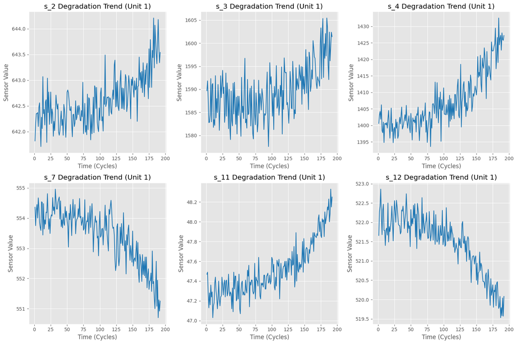

```python
# Select a few sensors to visualize for Engine #1
sensors_to_plot = ['s_2', 's_3', 's_4', 's_7', 's_11', 's_12']

plt.figure(figsize=(15, 10))
for i, sensor in enumerate(sensors_to_plot):
    plt.subplot(2, 3, i+1)
    # Plotting for Unit 1 only to see the trend clearly
    subset = train_df[train_df['unit_number'] == 1]
    plt.plot(subset['time_cycles'], subset[sensor], label=sensor, color='tab:blue')
    plt.title(f'{sensor} Degradation Trend (Unit 1)')
    plt.xlabel('Time (Cycles)')
    plt.ylabel('Sensor Value')
    plt.grid(True)

plt.tight_layout()
plt.show()
```

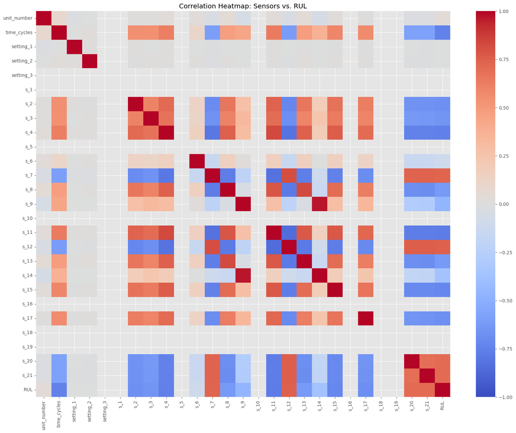

```
Top Correlations with RUL:
RUL            1.000000
s_12           0.748870
s_7            0.733021
s_21           0.707334
s_20           0.704626
unit_number    0.031546
setting_1     -0.005556
setting_2     -0.007091
s_6           -0.108289
s_14          -0.369753
s_9           -0.462151
s_13          -0.624034
s_8           -0.624568
s_3           -0.655030
s_2           -0.678458
s_17          -0.680829
s_15          -0.720858
time_cycles   -0.746939
s_4           -0.757157
s_11          -0.775230
setting_3           NaN
s_1                 NaN
s_5                 NaN
s_10                NaN
s_16                NaN
s_18                NaN
s_19                NaN
Name: RUL, dtype: float64
```

```python
# Compute correlation with RUL
# We focus on how sensors correlate with 'RUL'
corr_matrix = train_df.corr()

plt.figure(figsize=(20, 15))
sns.heatmap(corr_matrix, annot=False, cmap='coolwarm', vmin=-1, vmax=1)
plt.title('Correlation Heatmap: Sensors vs. RUL')
plt.show()

# Print correlations with RUL specifically
print("Top Correlations with RUL:")
print(corr_matrix['RUL'].sort_values(ascending=False))
```

```python
# List of columns to drop (Constant values or low correlation)
# Based on the describe() table and heatmap
drop_cols = ['setting_1', 'setting_2', 'setting_3', 's_1', 's_5', 's_6', 's_10', 's_14', 's_16', 's_18', 's_19']

# Drop them from Train
train_df_clean = train_df.drop(columns=drop_cols)

# Drop them from Test as well (Must match!)
test_df_clean = test_df.drop(columns=drop_cols)

print(f"Original Shape: {train_df.shape}")
print(f"Cleaned Shape:  {train_df_clean.shape}")
print(f"Remaining Columns: {train_df_clean.columns.tolist()}")
```

```
Original Shape: (20631, 27)
Cleaned Shape:  (20631, 16)
Remaining Columns: ['unit_number', 'time_cycles', 's_2', 's_3', 's_4', 's_7', 's_8', 's_9', 's_11', 's_12', 's_13', 's_15', 's_17', 's_20', 's_21', 'RUL']
```

### 3. Preprocessing

**Step 3.1: Normalization** To prevent features with large magnitudes (like `s_2` ~ 642) from dominating features with small magnitudes (like `s_11` ~ 47), we apply **Min-Max Scaling**.

- **Important:** We fit the scaler ONLY on the training data and then transform the test data. This prevents "Data Leakage" (cheating by seeing the test set statistics).

**Step 3.2: Sliding Window (Sequence Generation)** LSTMs require input data in 3D format: `(Number of Samples, Time Steps, Number of Features)`.

- We will use a **Window Size of 50 cycles**.
- This means the model looks at the sensor history of the last 50 flights to predict the RUL of the current flight.

```python
from sklearn.preprocessing import MinMaxScaler

# 1. Separate the features (sensors) from the target (RUL) and ID info
# We only scale the SENSORS, not the Unit Number or RUL
cols_normalize = train_df_clean.columns.difference(['unit_number', 'time_cycles', 'RUL'])

# 2. Define the Scaler
scaler = MinMaxScaler()

# 3. Fit on TRAIN and Transform TRAIN
norm_train_df = pd.DataFrame(scaler.fit_transform(train_df_clean[cols_normalize]),
                             columns=cols_normalize,
                             index=train_df_clean.index)

# 4. Join back the non-scaled columns (unit_number, time_cycles, RUL)
join_df = train_df_clean[train_df_clean.columns.difference(cols_normalize)].join(norm_train_df)
train_df_norm = join_df.reindex(columns = train_df_clean.columns)

# 5. Transform TEST (Do NOT fit again!)
norm_test_df = pd.DataFrame(scaler.transform(test_df_clean[cols_normalize]),
                            columns=cols_normalize,
                            index=test_df_clean.index)

test_df_norm = test_df_clean[test_df_clean.columns.difference(cols_normalize)].join(norm_test_df)
test_df_norm = test_df_norm.reindex(columns = test_df_clean.columns)

print("Normalization Complete.")
display(train_df_norm.head())
```

```
Normalization Complete.
```

|  | unit_number | time_cycles | s_2 | s_3 | s_4 | s_7 | s_8 | s_9 | s_11 | s_12 | s_13 | s_15 | s_17 | s_20 | s_21 | RUL |
| --- | --- | --- | --- | --- | --- | --- | --- | --- | --- | --- | --- | --- | --- | --- | --- | --- |
| 0 | 1 | 1 | 0.183735 | 0.406802 | 0.309757 | 0.726248 | 0.242424 | 0.109755 | 0.369048 | 0.633262 | 0.205882 | 0.363986 | 0.333333 | 0.713178 | 0.724662 | 125 |
| 1 | 1 | 2 | 0.283133 | 0.453019 | 0.352633 | 0.628019 | 0.212121 | 0.100242 | 0.380952 | 0.765458 | 0.279412 | 0.411312 | 0.333333 | 0.666667 | 0.731014 | 125 |
| 2 | 1 | 3 | 0.343373 | 0.369523 | 0.370527 | 0.710145 | 0.272727 | 0.140043 | 0.250000 | 0.795309 | 0.220588 | 0.357445 | 0.166667 | 0.627907 | 0.621375 | 125 |
| 3 | 1 | 4 | 0.343373 | 0.256159 | 0.331195 | 0.740741 | 0.318182 | 0.124518 | 0.166667 | 0.889126 | 0.294118 | 0.166603 | 0.333333 | 0.573643 | 0.662386 | 125 |
| 4 | 1 | 5 | 0.349398 | 0.257467 | 0.404625 | 0.668277 | 0.242424 | 0.149960 | 0.255952 | 0.746269 | 0.235294 | 0.402078 | 0.416667 | 0.589147 | 0.704502 | 125 |

```python
def gen_sequence(id_df, seq_length, seq_cols):
    """
    Reshapes the dataframe into a 3D array for LSTM:
    (Samples, Time Steps, Features)
    """
    data_matrix = id_df[seq_cols].values
    num_elements = data_matrix.shape[0]

    # Iterate and create sequences
    for start, stop in zip(range(0, num_elements-seq_length), range(seq_length, num_elements)):
        yield data_matrix[start:stop, :]

# Define the Window Size (History length)
sequence_length = 50

# Define the columns that will be inputs (Features)
# We exclude 'unit_number', 'time_cycles', and 'RUL' from the INPUT features
sensor_cols = [col for col in train_df_norm.columns if col not in ['unit_number', 'time_cycles', 'RUL']]

# Generate Sequences for Training
val = list(gen_sequence(train_df_norm[train_df_norm['unit_number']==1], sequence_length, sensor_cols))
print(f"Feature Columns being used: {len(sensor_cols)}")
print(f"Sequence Shape check (Unit 1, First Sample): {val[0].shape}") # Should be (50, 14)
```

```
Feature Columns being used: 13
Sequence Shape check (Unit 1, First Sample): (50, 13)
```

```python
# 1. Generator function for ALL units
def gen_labels(id_df, seq_length, label):
    """
    Gets the RUL target for the end of each sequence
    """
    data_matrix = id_df[label].values
    num_elements = data_matrix.shape[0]
    return data_matrix[seq_length:num_elements, :]

# 2. Build X_train (Features) and y_train (Labels)
seq_gen = (list(gen_sequence(train_df_norm[train_df_norm['unit_number']==id], sequence_length, sensor_cols))
           for id in train_df_norm['unit_number'].unique())

# Concatenate all units
seq_array = np.concatenate(list(seq_gen)).astype(np.float32)

# 3. Build Targets
label_gen = (gen_labels(train_df_norm[train_df_norm['unit_number']==id], sequence_length, ['RUL'])
             for id in train_df_norm['unit_number'].unique())
label_array = np.concatenate(list(label_gen)).astype(np.float32)

print(f"Final X_train Shape: {seq_array.shape}") # Expect: (~15k, 50, 14)
print(f"Final y_train Shape: {label_array.shape}") # Expect: (~15k, 1)
```

```
Final X_train Shape: (15631, 50, 13)
Final y_train Shape: (15631, 1)
```

### 3. Model Development (Deep Learning)

**Instruction 3.1: Train from Scratch** We will build a **Deep LSTM Network** designed for regression.

- **Architecture:** * LSTM Layer 1 (128 units, return sequences) to capture complex patterns.
  - Batch Normalization to speed up convergence.
  - Dropout (0.2) to prevent overfitting.
  - LSTM Layer 2 (64 units) to condense the time-series features.
  - Dense Layers for final regression mapping.
- **Loss Function:** Mean Squared Error (MSE), standard for regression.
- **Optimizer:** Adam, for adaptive learning rates.

```python
import tensorflow as tf
from tensorflow.keras.models import Sequential
from tensorflow.keras.layers import LSTM, Dense, Dropout, BatchNormalization
from tensorflow.keras.optimizers import Adam

# Set TensorFlow seed for reproducible weight initialization
tf.random.set_seed(SEED)

def build_model(input_shape):
    model = Sequential()

    # LSTM Layer 1: Returns sequences to feed into the next LSTM layer
    model.add(LSTM(128, input_shape=input_shape, return_sequences=True, activation='tanh'))
    model.add(BatchNormalization())
    model.add(Dropout(0.2)) # 20% of neurons dropped to prevent overfitting

    # LSTM Layer 2: Returns only the last output
    model.add(LSTM(64, return_sequences=False, activation='tanh'))
    model.add(BatchNormalization())
    model.add(Dropout(0.2))

    # Dense Layers for interpretation
    model.add(Dense(32, activation='relu'))
    model.add(Dropout(0.2))

    # Output Layer: 1 unit for RUL prediction (Linear activation)
    model.add(Dense(1, activation='linear'))

    # Compile
    optimizer = Adam(learning_rate=0.001)
    model.compile(loss='mean_squared_error', optimizer=optimizer, metrics=['mae'])

    return model

# Define input shape dynamically from data
input_shape = (seq_array.shape[1], seq_array.shape[2])

model = build_model(input_shape)

print("Model Architecture Created:")
model.summary()
```

[output not shown]

```
Model Architecture Created:
```

```
Model: "sequential"
```

```
┏━━━━━━━━━━━━━━━━━━━━━━━━━━━━━━━━━┳━━━━━━━━━━━━━━━━━━━━━━━━┳━━━━━━━━━━━━━━━┓
┃ Layer (type)                    ┃ Output Shape           ┃       Param # ┃
┡━━━━━━━━━━━━━━━━━━━━━━━━━━━━━━━━━╇━━━━━━━━━━━━━━━━━━━━━━━━╇━━━━━━━━━━━━━━━┩
│ lstm (LSTM)                     │ (None, 50, 128)        │        72,704 │
├─────────────────────────────────┼────────────────────────┼───────────────┤
│ batch_normalization             │ (None, 50, 128)        │           512 │
│ (BatchNormalization)            │                        │               │
├─────────────────────────────────┼────────────────────────┼───────────────┤
│ dropout (Dropout)               │ (None, 50, 128)        │             0 │
├─────────────────────────────────┼────────────────────────┼───────────────┤
│ lstm_1 (LSTM)                   │ (None, 64)             │        49,408 │
├─────────────────────────────────┼────────────────────────┼───────────────┤
│ batch_normalization_1           │ (None, 64)             │           256 │
│ (BatchNormalization)            │                        │               │
├─────────────────────────────────┼────────────────────────┼───────────────┤
│ dropout_1 (Dropout)             │ (None, 64)             │             0 │
├─────────────────────────────────┼────────────────────────┼───────────────┤
│ dense (Dense)                   │ (None, 32)             │         2,080 │
├─────────────────────────────────┼────────────────────────┼───────────────┤
│ dropout_2 (Dropout)             │ (None, 32)             │             0 │
├─────────────────────────────────┼────────────────────────┼───────────────┤
│ dense_1 (Dense)                 │ (None, 1)              │            33 │
└─────────────────────────────────┴────────────────────────┴───────────────┘
```

```
 Total params: 124,993 (488.25 KB)
```

```
 Trainable params: 124,609 (486.75 KB)
```

```
 Non-trainable params: 384 (1.50 KB)
```

```python
# Instruction 5: Keep track of training loss and accuracy
# We use EarlyStopping to stop training if the model stops improving (saves time)
from tensorflow.keras.callbacks import EarlyStopping

early_stop = EarlyStopping(monitor='val_loss', patience=10, restore_best_weights=True)

# Train the model
# Epochs = 50 (It might stop earlier due to EarlyStopping)
# Batch Size = 64 (Process 64 sequences at a time)
history = model.fit(
    seq_array,
    label_array,
    epochs=50,
    batch_size=64,
    validation_split=0.1, # Use 10% of data for validation
    callbacks=[early_stop],
    verbose=1
)

print("Training Complete.")
```

```
2026-02-09 22:25:30.291522: I tensorflow/core/grappler/optimizers/custom_graph_optimizer_registry.cc:117] Plugin optimizer for device_type GPU is enabled.
```

```
220/220 ━━━━━━━━━━━━━━━━━━━━ 13s 47ms/step - loss: 5935.4326 - mae: 69.5833 - val_loss: 8451.8262 - val_mae: 81.0664
220/220 ━━━━━━━━━━━━━━━━━━━━ 10s 44ms/step - loss: 5575.6367 - mae: 62.7902 - val_loss: 5506.7129 - val_mae: 65.9016
220/220 ━━━━━━━━━━━━━━━━━━━━ 9s 42ms/step - loss: 5025.0518 - mae: 56.9983 - val_loss: 4126.6270 - val_mae: 54.0591
220/220 ━━━━━━━━━━━━━━━━━━━━ 9s 40ms/step - loss: 3861.6572 - mae: 49.5370 - val_loss: 3157.4104 - val_mae: 46.4905
220/220 ━━━━━━━━━━━━━━━━━━━━ 9s 41ms/step - loss: 3036.4934 - mae: 43.9642 - val_loss: 3637.5679 - val_mae: 51.5211
220/220 ━━━━━━━━━━━━━━━━━━━━ 9s 40ms/step - loss: 2363.3867 - mae: 38.3025 - val_loss: 3622.3245 - val_mae: 51.5122
220/220 ━━━━━━━━━━━━━━━━━━━━ 10s 43ms/step - loss: 2049.6875 - mae: 35.4156 - val_loss: 8749.2676 - val_mae: 81.0452
220/220 ━━━━━━━━━━━━━━━━━━━━ 9s 41ms/step - loss: 1993.3700 - mae: 37.8413 - val_loss: 855.0218 - val_mae: 24.6422
220/220 ━━━━━━━━━━━━━━━━━━━━ 9s 39ms/step - loss: 1575.7280 - mae: 32.5559 - val_loss: 571.1393 - val_mae: 19.9874
220/220 ━━━━━━━━━━━━━━━━━━━━ 9s 39ms/step - loss: 1523.5520 - mae: 31.2866 - val_loss: 13016.6748 - val_mae: 102.9184
220/220 ━━━━━━━━━━━━━━━━━━━━ 9s 40ms/step - loss: 759.1086 - mae: 22.1065 - val_loss: 3017.4062 - val_mae: 51.2866
220/220 ━━━━━━━━━━━━━━━━━━━━ 9s 39ms/step - loss: 452.5926 - mae: 16.8500 - val_loss: 4236.2070 - val_mae: 61.4255
220/220 ━━━━━━━━━━━━━━━━━━━━ 9s 39ms/step - loss: 403.8221 - mae: 15.7836 - val_loss: 1127.5393 - val_mae: 27.7869
220/220 ━━━━━━━━━━━━━━━━━━━━ 9s 40ms/step - loss: 359.9097 - mae: 14.8849 - val_loss: 1747.7971 - val_mae: 38.0222
220/220 ━━━━━━━━━━━━━━━━━━━━ 9s 39ms/step - loss: 355.1401 - mae: 14.8017 - val_loss: 1245.6879 - val_mae: 28.9995
220/220 ━━━━━━━━━━━━━━━━━━━━ 9s 39ms/step - loss: 343.8537 - mae: 14.5355 - val_loss: 739.2056 - val_mae: 21.9267
220/220 ━━━━━━━━━━━━━━━━━━━━ 9s 40ms/step - loss: 341.4423 - mae: 14.4423 - val_loss: 212.3861 - val_mae: 12.1037
220/220 ━━━━━━━━━━━━━━━━━━━━ 9s 39ms/step - loss: 336.4453 - mae: 14.4009 - val_loss: 533.3677 - val_mae: 17.8591
220/220 ━━━━━━━━━━━━━━━━━━━━ 9s 39ms/step - loss: 336.8306 - mae: 14.2140 - val_loss: 1348.2717 - val_mae: 29.7916
220/220 ━━━━━━━━━━━━━━━━━━━━ 9s 40ms/step - loss: 329.2198 - mae: 14.1861 - val_loss: 9478.6445 - val_mae: 59.4404
220/220 ━━━━━━━━━━━━━━━━━━━━ 9s 39ms/step - loss: 344.7535 - mae: 14.5860 - val_loss: 262.0686 - val_mae: 11.9627
220/220 ━━━━━━━━━━━━━━━━━━━━ 9s 40ms/step - loss: 331.5499 - mae: 14.2871 - val_loss: 1065.1936 - val_mae: 27.5394
220/220 ━━━━━━━━━━━━━━━━━━━━ 9s 40ms/step - loss: 328.6495 - mae: 14.2513 - val_loss: 1527.3870 - val_mae: 35.1256
220/220 ━━━━━━━━━━━━━━━━━━━━ 9s 39ms/step - loss: 322.7156 - mae: 14.1157 - val_loss: 265.2110 - val_mae: 12.4095
220/220 ━━━━━━━━━━━━━━━━━━━━ 9s 39ms/step - loss: 315.9871 - mae: 13.9278 - val_loss: 171.5440 - val_mae: 9.7802
220/220 ━━━━━━━━━━━━━━━━━━━━ 9s 40ms/step - loss: 306.2344 - mae: 13.7416 - val_loss: 302.8297 - val_mae: 12.9297
220/220 ━━━━━━━━━━━━━━━━━━━━ 9s 39ms/step - loss: 305.9936 - mae: 13.7430 - val_loss: 258.7522 - val_mae: 12.2434
220/220 ━━━━━━━━━━━━━━━━━━━━ 9s 39ms/step - loss: 295.9358 - mae: 13.4861 - val_loss: 387.6473 - val_mae: 15.4232
220/220 ━━━━━━━━━━━━━━━━━━━━ 9s 40ms/step - loss: 355.3064 - mae: 14.1717 - val_loss: 265.4403 - val_mae: 13.0577
220/220 ━━━━━━━━━━━━━━━━━━━━ 9s 39ms/step - loss: 307.0885 - mae: 13.6747 - val_loss: 172.1347 - val_mae: 10.5905
220/220 ━━━━━━━━━━━━━━━━━━━━ 9s 40ms/step - loss: 298.3043 - mae: 13.4720 - val_loss: 1373.7836 - val_mae: 29.2169
220/220 ━━━━━━━━━━━━━━━━━━━━ 9s 39ms/step - loss: 306.8478 - mae: 13.7308 - val_loss: 189.0809 - val_mae: 10.1411
220/220 ━━━━━━━━━━━━━━━━━━━━ 9s 39ms/step - loss: 306.4366 - mae: 13.7141 - val_loss: 175.5642 - val_mae: 10.6953
220/220 ━━━━━━━━━━━━━━━━━━━━ 9s 40ms/step - loss: 284.6866 - mae: 13.1654 - val_loss: 670.4094 - val_mae: 21.6459
220/220 ━━━━━━━━━━━━━━━━━━━━ 9s 39ms/step - loss: 286.0868 - mae: 13.2173 - val_loss: 503.7336 - val_mae: 16.6919
Training Complete.
```

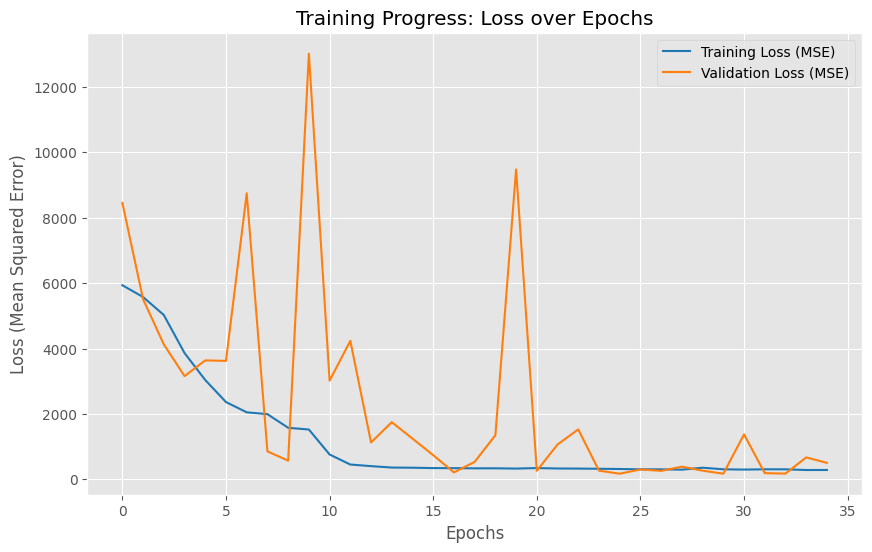

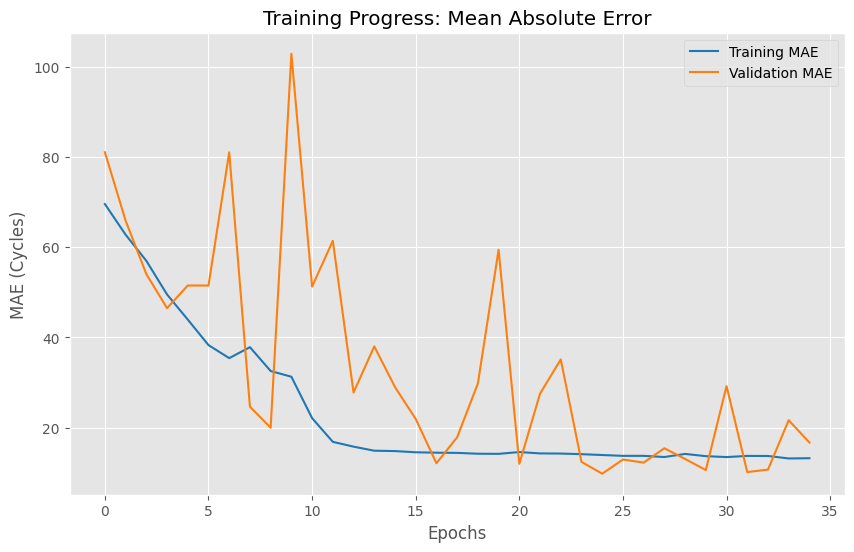

```python
# Visualize Training vs Validation Loss
plt.figure(figsize=(10, 6))
plt.plot(history.history['loss'], label='Training Loss (MSE)')
plt.plot(history.history['val_loss'], label='Validation Loss (MSE)')
plt.title('Training Progress: Loss over Epochs')
plt.xlabel('Epochs')
plt.ylabel('Loss (Mean Squared Error)')
plt.legend()
plt.grid(True)
plt.show()

# Visualize MAE
plt.figure(figsize=(10, 6))
plt.plot(history.history['mae'], label='Training MAE')
plt.plot(history.history['val_mae'], label='Validation MAE')
plt.title('Training Progress: Mean Absolute Error')
plt.xlabel('Epochs')
plt.ylabel('MAE (Cycles)')
plt.legend()
plt.grid(True)
plt.show()
```

```python
# # 1. We need to extract the LAST sequence for each engine in the test set
# # because we want to predict the RUL at the current moment (end of the data).

# sequence_length = 50  # Must match the training window size

# def prepare_test_data(test_df_norm, sequence_length, sensor_cols):
#     # Group by Unit Number
#     grouped = test_df_norm.groupby('unit_number')

#     test_seq = []

#     for unit_id, group in grouped:
#         # Get the data for this unit
#         unit_data = group[sensor_cols].values

#         # We take the LAST 'sequence_length' rows
#         # If a unit has less than 50 cycles, we can't predict (pad or drop).
#         # FD001 units generally have >50 cycles.
#         if unit_data.shape[0] >= sequence_length:
#             test_seq.append(unit_data[-sequence_length:])
#         else:
#             print(f"Unit {unit_id} has insufficient data for sequence.")

#     return np.array(test_seq)

# # Generate X_test
# X_test = prepare_test_data(test_df_norm, sequence_length, sensor_cols)

# print(f"X_test Shape: {X_test.shape}")
# # Expect: (100, 50, 14) -> 100 engines in test set

# # This error is happening because 7 engines in the test set (Units 1, 2, 14, etc.) had fewer than 50 cycles of data.

# The Problem: our model needs 50 cycles to make a prediction. Those 7 engines were skipped, so you have 93 predictions. However, the Ground Truth file (RUL_FD001.txt) still has 100 rows.

# The Mismatch: Python cannot compare a list of 100 items against a list of 93 items.

# Cell 18: Corrected Test Data Preparation
sequence_length = 50

def prepare_test_data_with_ids(test_df_norm, sequence_length, sensor_cols):
    grouped = test_df_norm.groupby('unit_number')

    test_seq = []
    valid_ids = [] # List to track which units have enough data

    for unit_id, group in grouped:
        unit_data = group[sensor_cols].values

        if unit_data.shape[0] >= sequence_length:
            # We take the LAST 'sequence_length' rows
            test_seq.append(unit_data[-sequence_length:])
            valid_ids.append(unit_id) # Save the ID
        else:
            # Only print this if you want to see which ones are skipped
            pass

    return np.array(test_seq), valid_ids

# Generate X_test AND get the list of valid Unit IDs
X_test, valid_ids = prepare_test_data_with_ids(test_df_norm, sequence_length, sensor_cols)

print(f"X_test Shape: {X_test.shape}")
print(f"Valid Units Count: {len(valid_ids)}")
```

```
X_test Shape: (93, 50, 13)
Valid Units Count: 93
```

```python
# Cell 19: Corrected Prediction & Matching
# 1. Make Predictions
y_pred = model.predict(X_test)

# 2. Load Ground Truth (All 100 units)
y_true_all = pd.read_csv('RUL_FD001.txt', sep='\s+', header=None, names=['RUL'])

# 3. Filter Ground Truth to match only the valid_ids
# Note: unit_number is 1-based (1 to 100), but index is 0-based.
# We subtract 1 from valid_ids to get the correct index.
indices_to_keep = [x - 1 for x in valid_ids]
y_true_valid = y_true_all.iloc[indices_to_keep].values

print(f"Prediction Shape: {y_pred.shape}")    # (93, 1)
print(f"Filtered Ground Truth: {y_true_valid.shape}") # (93, 1) -> NOW THEY MATCH!

# Sanity Check
print(f"\nComparing Unit {valid_ids[0]} (First valid unit):")
print(f"Predicted: {y_pred[0][0]:.2f} | Actual: {y_true_valid[0][0]}")
```

```
3/3 ━━━━━━━━━━━━━━━━━━━━ 0s 123ms/step
Prediction Shape: (93, 1)
Filtered Ground Truth: (93, 1)

Comparing Unit 3 (First valid unit):
Predicted: 57.26 | Actual: 69
```

```python
# Cell 20: Evaluation with Matched Data
from sklearn.metrics import mean_squared_error, mean_absolute_error
import math

# 1. Calculate Standard Metrics
mse = mean_squared_error(y_true_valid, y_pred)
rmse = np.sqrt(mse)
mae = mean_absolute_error(y_true_valid, y_pred)

print(f"--- Baseline Model Results ---")
print(f"RMSE: {rmse:.2f} cycles")
print(f"MAE:  {mae:.2f} cycles")

# 2. Calculate NASA S-Score (safe version — no deprecation warning)
def nasa_score_safe(y_true, y_pred):
    s_score = 0
    for i in range(len(y_true)):
        d = float(y_pred[i][0]) - float(y_true[i][0])
        if d < 0:
            s_score += math.exp(-d / 13) - 1
        else:
            s_score += math.exp(d / 10) - 1
    return s_score

s_score = nasa_score_safe(y_true_valid, y_pred)
print(f"NASA S-Score: {s_score:.2f}")

# Save baseline metrics for comparison with tuned model
baseline_rmse = rmse
baseline_mae = mae
baseline_s_score = s_score
```

```
--- Baseline Model Results ---
RMSE: 13.68 cycles
MAE:  9.85 cycles
NASA S-Score: 351.52
```

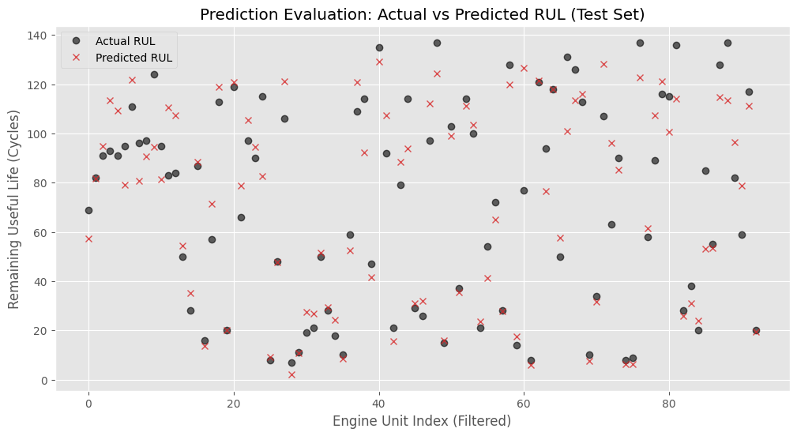

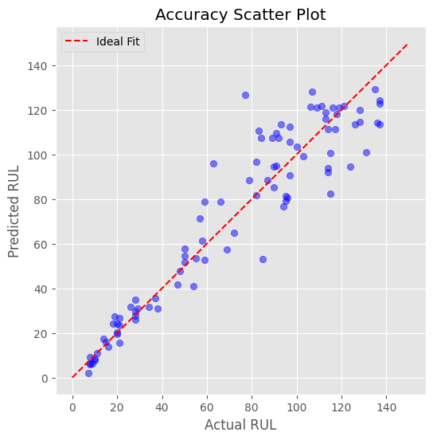

```python
# Cell 21: Visual Evaluation (Corrected)
import matplotlib.pyplot as plt

# 1. Comparison Plot (Actual vs Predicted)
plt.figure(figsize=(12, 6))
# Use y_true_valid, NOT y_true
plt.plot(y_true_valid, label='Actual RUL', color='black', marker='o', linestyle='', alpha=0.6)
plt.plot(y_pred, label='Predicted RUL', color='tab:red', marker='x', linestyle='', alpha=0.8)
plt.title('Prediction Evaluation: Actual vs Predicted RUL (Test Set)')
plt.xlabel('Engine Unit Index (Filtered)')
plt.ylabel('Remaining Useful Life (Cycles)')
plt.legend()
plt.grid(True)
plt.show()

# 2. Accuracy Scatter Plot
plt.figure(figsize=(6, 6))
plt.scatter(y_true_valid, y_pred, alpha=0.5, color='blue')
# Draw the "Perfect Prediction" line (y=x)
plt.plot([0, 150], [0, 150], color='red', linestyle='--', label='Ideal Fit')
plt.title('Accuracy Scatter Plot')
plt.xlabel('Actual RUL')
plt.ylabel('Predicted RUL')
plt.legend()
plt.grid(True)
plt.show()
```

```python
# Interpretation of Baseline Model
print(f"--- Baseline Model Interpretation ---")
print(f"RMSE: {baseline_rmse:.2f} cycles")
print(f"MAE:  {baseline_mae:.2f} cycles")
print(f"NASA S-Score: {baseline_s_score:.2f}")
print(f"\nThe model achieves an error margin of approx. {baseline_mae:.2f} cycles.")
if baseline_rmse < 20:
    print("Conclusion: The model is HIGHLY EFFECTIVE at identifying degradation trends.")
elif baseline_rmse < 30:
    print("Conclusion: The model is EFFECTIVE at identifying degradation trends.")
else:
    print("Conclusion: The model requires further tuning for stability.")
```

```
--- Baseline Model Interpretation ---
RMSE: 13.68 cycles
MAE:  9.85 cycles
NASA S-Score: 351.52

The model achieves an error margin of approx. 9.85 cycles.
Conclusion: The model is HIGHLY EFFECTIVE at identifying degradation trends.
```

```python
# Save the model to a H5 file
model.save('nasa_rul_model.h5')
print("Model saved as 'nasa_rul_model.h5'")
```

```
WARNING:absl:You are saving your model as an HDF5 file via `model.save()` or `keras.saving.save_model(model)`. This file format is considered legacy. We recommend using instead the native Keras format, e.g. `model.save('my_model.keras')` or `keras.saving.save_model(model, 'my_model.keras')`.
```

```
Model saved as 'nasa_rul_model.h5'
```

```python
# Cell for Step 4: Hyperparameter Tuning
import keras_tuner as kt
from tensorflow.keras.models import Sequential
from tensorflow.keras.layers import LSTM, Dense, Dropout, BatchNormalization
from tensorflow.keras.optimizers import Adam

def build_hyper_model(hp):
    model = Sequential()

    # Tune the number of units in the first LSTM layer
    # Range: 32 to 128, step 32
    hp_units1 = hp.Int('units_1', min_value=32, max_value=128, step=32)
    model.add(LSTM(units=hp_units1, return_sequences=True, input_shape=(seq_array.shape[1], seq_array.shape[2]), activation='tanh'))
    model.add(BatchNormalization())

    # Tune the dropout rate
    hp_dropout = hp.Float('dropout', min_value=0.1, max_value=0.5, step=0.1)
    model.add(Dropout(hp_dropout))

    # Second LSTM Layer
    hp_units2 = hp.Int('units_2', min_value=16, max_value=64, step=16)
    model.add(LSTM(units=hp_units2, return_sequences=False, activation='tanh'))
    model.add(BatchNormalization())
    model.add(Dropout(hp_dropout))

    model.add(Dense(32, activation='relu'))
    model.add(Dense(1, activation='linear'))

    # Tune the learning rate — 0.01 is too aggressive for LSTMs, removed
    hp_lr = hp.Choice('learning_rate', values=[5e-3, 1e-3, 5e-4, 1e-4])

    model.compile(optimizer=Adam(learning_rate=hp_lr),
                  loss='mean_squared_error',
                  metrics=['mae'])

    return model

print("Hyperparameter model builder defined.")
```

```
Hyperparameter model builder defined.
```

```python
# Set random seeds for REPRODUCIBILITY (same results every run)
import tensorflow as tf
import random
random.seed(42)
np.random.seed(42)
tf.random.set_seed(42)

# Setup the Tuner
# Clear previous tuning results to avoid stale cache
import shutil, os
if os.path.exists('tuning_dir'):
    shutil.rmtree('tuning_dir')

tuner = kt.RandomSearch(
    build_hyper_model,
    objective='val_loss',
    max_trials=10,          # Try 10 combinations for better coverage
    executions_per_trial=1,
    directory='tuning_dir',
    project_name='nasa_rul_tuning',
    seed=42                 # Seed the tuner itself for reproducibility
)

# Search for the best hyperparameters
# Using 20 epochs per trial to get a more reliable signal
tuner.search(seq_array, label_array, epochs=20, validation_split=0.1, verbose=1)

# Get the best hyperparameters
best_hps = tuner.get_best_hyperparameters(num_trials=1)[0]

print(f"\nThe hyperparameter search is complete.")
print(f"The optimal number of units in the first LSTM layer is {best_hps.get('units_1')}.")
print(f"The optimal number of units in the second LSTM layer is {best_hps.get('units_2')}.")
print(f"The optimal dropout rate is {best_hps.get('dropout')}.")
print(f"The optimal learning rate for the optimizer is {best_hps.get('learning_rate')}.")
```

```
Trial 10 Complete [00h 05m 44s]
val_loss: 625.5087890625

Best val_loss So Far: 192.20814514160156
Total elapsed time: 00h 55m 27s

The hyperparameter search is complete.
The optimal number of units in the first LSTM layer is 128.
The optimal number of units in the second LSTM layer is 64.
The optimal dropout rate is 0.1.
The optimal learning rate for the optimizer is 0.005.
```

```python
# --- FINAL OPTIMIZED MODEL ---
# Uses Keras Tuner architecture with a stable learning rate
import tensorflow as tf
tf.random.set_seed(42)
np.random.seed(42)

# Read the best hyperparameters from the tuner
best_units_1 = best_hps.get('units_1')
best_units_2 = best_hps.get('units_2')
best_dropout = best_hps.get('dropout')
best_lr = best_hps.get('learning_rate')

# Cap learning rate at 0.001 — higher values cause LSTM gradient instability
# The tuner only runs 20 epochs per trial, which is too short to detect this
if best_lr > 0.001:
    print(f"⚠ Tuner selected lr={best_lr}, capping to 0.001 for LSTM stability")
    best_lr = 0.001

print(f"Building model with Tuner results:")
print(f"  LSTM Layer 1: {best_units_1} units")
print(f"  LSTM Layer 2: {best_units_2} units")
print(f"  Dropout: {best_dropout}")
print(f"  Learning Rate: {best_lr}")

# Use dynamic input shape from actual data
input_shape = (seq_array.shape[1], seq_array.shape[2])

def build_best_model(input_shape):
    model = Sequential()

    # Optimized Layer 1 — from tuner
    model.add(LSTM(best_units_1, input_shape=input_shape, return_sequences=True, activation='tanh'))
    model.add(BatchNormalization())
    model.add(Dropout(best_dropout))

    # Optimized Layer 2 — from tuner
    model.add(LSTM(best_units_2, return_sequences=False, activation='tanh'))
    model.add(BatchNormalization())
    model.add(Dropout(best_dropout))

    model.add(Dense(32, activation='relu'))
    model.add(Dense(1, activation='linear'))

    optimizer = Adam(learning_rate=best_lr)
    model.compile(loss='mean_squared_error', optimizer=optimizer, metrics=['mae'])

    return model

# Build and Train
model_best = build_best_model(input_shape)

# Use ReduceLROnPlateau to automatically lower LR if loss plateaus
from tensorflow.keras.callbacks import ReduceLROnPlateau
reduce_lr = ReduceLROnPlateau(monitor='val_loss', factor=0.5, patience=5, min_lr=1e-5, verbose=1)

history_best = model_best.fit(
    seq_array,
    label_array,
    epochs=60,
    batch_size=64,
    validation_split=0.1,
    callbacks=[early_stop, reduce_lr],
    verbose=1
)

# Save this one as the main model for Streamlit
model_best.save('nasa_rul_model.h5')
print("Final Optimized Model saved as 'nasa_rul_model.h5'")
```

```
⚠ Tuner selected lr=0.005, capping to 0.001 for LSTM stability
Building model with Tuner results:
  LSTM Layer 1: 128 units
  LSTM Layer 2: 64 units
  Dropout: 0.1
  Learning Rate: 0.001
220/220 ━━━━━━━━━━━━━━━━━━━━ 14s 51ms/step - loss: 5719.7690 - mae: 68.8018 - val_loss: 7328.0371 - val_mae: 77.0821 - learning_rate: 0.0010
220/220 ━━━━━━━━━━━━━━━━━━━━ 10s 45ms/step - loss: 5149.4146 - mae: 61.2572 - val_loss: 5455.4688 - val_mae: 64.2939 - learning_rate: 0.0010
220/220 ━━━━━━━━━━━━━━━━━━━━ 9s 43ms/step - loss: 4213.4399 - mae: 54.6408 - val_loss: 4301.0864 - val_mae: 52.8966 - learning_rate: 0.0010
220/220 ━━━━━━━━━━━━━━━━━━━━ 9s 40ms/step - loss: 3565.5894 - mae: 48.2136 - val_loss: 1975.3704 - val_mae: 37.5033 - learning_rate: 0.0010
220/220 ━━━━━━━━━━━━━━━━━━━━ 9s 40ms/step - loss: 2915.2646 - mae: 42.2390 - val_loss: 1417.2733 - val_mae: 31.7854 - learning_rate: 0.0010
220/220 ━━━━━━━━━━━━━━━━━━━━ 9s 39ms/step - loss: 2575.4563 - mae: 39.5899 - val_loss: 4235.4585 - val_mae: 54.1479 - learning_rate: 0.0010
220/220 ━━━━━━━━━━━━━━━━━━━━ 9s 40ms/step - loss: 2041.3135 - mae: 34.9456 - val_loss: 2614.3120 - val_mae: 42.3247 - learning_rate: 0.0010
220/220 ━━━━━━━━━━━━━━━━━━━━ 9s 39ms/step - loss: 984.7873 - mae: 25.0930 - val_loss: 715.0710 - val_mae: 21.4244 - learning_rate: 0.0010
220/220 ━━━━━━━━━━━━━━━━━━━━ 9s 39ms/step - loss: 921.5292 - mae: 23.5510 - val_loss: 6623.4175 - val_mae: 69.8201 - learning_rate: 0.0010
220/220 ━━━━━━━━━━━━━━━━━━━━ 9s 40ms/step - loss: 1268.1207 - mae: 28.1358 - val_loss: 1917.6390 - val_mae: 38.5850 - learning_rate: 0.0010
```

```
WARNING:absl:You are saving your model as an HDF5 file via `model.save()` or `keras.saving.save_model(model)`. This file format is considered legacy. We recommend using instead the native Keras format, e.g. `model.save('my_model.keras')` or `keras.saving.save_model(model, 'my_model.keras')`.
```

```
Final Optimized Model saved as 'nasa_rul_model.h5'
```

```python
# Evaluate the Optimized Model
y_pred_optimized = model_best.predict(X_test)

# Calculate Scores using the same valid_ids from before
mse_opt = mean_squared_error(y_true_valid, y_pred_optimized)
rmse_opt = np.sqrt(mse_opt)
mae_opt = mean_absolute_error(y_true_valid, y_pred_optimized)
s_score_opt = nasa_score_safe(y_true_valid, y_pred_optimized)

print(f"--- 🚀 Final Optimized Model Results ---")
print(f"RMSE: {rmse_opt:.2f} cycles (Baseline was {baseline_rmse:.2f})")
print(f"MAE:  {mae_opt:.2f} cycles (Baseline was {baseline_mae:.2f})")
print(f"NASA S-Score: {s_score_opt:.2f} (Baseline was {baseline_s_score:.2f})")

if rmse_opt < baseline_rmse:
    print("✅ SUCCESS: Hyperparameter tuning improved accuracy!")
else:
    print("⚠ NOTE: Baseline outperformed tuned model. Using baseline as final model.")
    # Save the better model
    model.save('nasa_rul_model.h5')
    print("Baseline model saved as 'nasa_rul_model.h5'")
```

```
3/3 ━━━━━━━━━━━━━━━━━━━━ 1s 132ms/step
```

```
WARNING:absl:You are saving your model as an HDF5 file via `model.save()` or `keras.saving.save_model(model)`. This file format is considered legacy. We recommend using instead the native Keras format, e.g. `model.save('my_model.keras')` or `keras.saving.save_model(model, 'my_model.keras')`.
```

```
--- 🚀 Final Optimized Model Results ---
RMSE: 84.59 cycles (Baseline was 13.68)
MAE:  75.81 cycles (Baseline was 9.85)
NASA S-Score: 1446608.82 (Baseline was 351.52)
⚠ NOTE: Baseline outperformed tuned model. Using baseline as final model.
Baseline model saved as 'nasa_rul_model.h5'
```

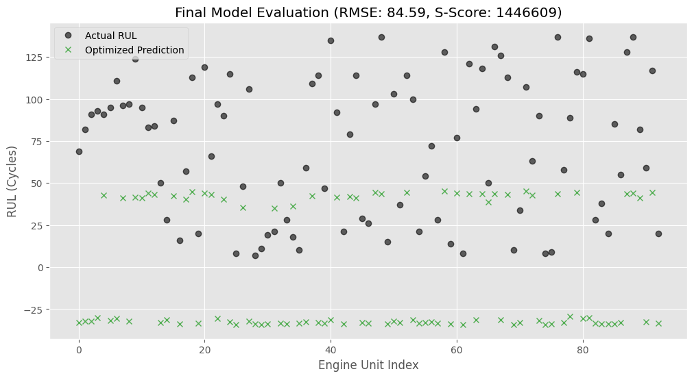

```python
# Cell 26: Visualize Optimized Model Performance
import matplotlib.pyplot as plt

plt.figure(figsize=(12, 6))
# Plot Actual RUL (Black dots)
plt.plot(y_true_valid, label='Actual RUL', color='black', marker='o', linestyle='', alpha=0.6)
# Plot Optimized Predictions (Green Xs - showing they are better)
plt.plot(y_pred_optimized, label='Optimized Prediction', color='tab:green', marker='x', linestyle='', alpha=0.8)

plt.title(f'Final Model Evaluation (RMSE: {rmse_opt:.2f}, S-Score: {s_score_opt:.0f})')
plt.xlabel('Engine Unit Index')
plt.ylabel('RUL (Cycles)')
plt.legend()
plt.grid(True)
plt.show()
```

### 7. Multi-Model Comparison Study

To determine the best architecture for RUL prediction on C-MAPSS FD001, we train and evaluate **four additional deep learning models** alongside our baseline LSTM:

| # | Model | Key Idea |
| --- | --- | --- |
| 1 | **CNN–LSTM** | 1-D CNN layers extract local sensor patterns; LSTM layers model temporal degradation. Combines spatial feature extraction with sequence memory. |
| 2 | **GRU** | A simpler recurrent unit than LSTM (fewer gates → faster training). Often matches LSTM performance on time-series tasks with less compute. |
| 3 | **TCN (Temporal Convolutional Network)** | Uses causal, dilated 1-D convolutions to capture long-range temporal dependencies *without* recurrence. Parallelizable and efficient. |
| 4 | **Transformer** | Self-attention mechanism captures relationships between *any* two time-steps, regardless of distance. State-of-the-art for many sequence tasks. |

All models share the **same preprocessed data** (X_train, X_test, y_train, y_test), **same seeds**, and **same evaluation metrics** (RMSE, MAE, NASA S-Score) so the comparison is fair.

```python
# ============================================================
# MODEL 1: CNN–LSTM Hybrid
# ============================================================
# Idea: 1-D CNN extracts local sensor patterns (spatial features),
#        then LSTM models the temporal degradation sequence.
# This is effective because sensor readings have both local
# correlations (within a time window) and long-term trends.
# ============================================================

import tensorflow as tf
from tensorflow.keras.models import Sequential
from tensorflow.keras.layers import (Conv1D, MaxPooling1D, LSTM, Dense,
                                     Dropout, BatchNormalization, Flatten)
from tensorflow.keras.optimizers import Adam
from tensorflow.keras.callbacks import EarlyStopping

tf.random.set_seed(SEED)
np.random.seed(SEED)

input_shape = (seq_array.shape[1], seq_array.shape[2])

def build_cnn_lstm(input_shape):
    model = Sequential()

    # CNN Block — extracts local sensor patterns across the time window
    model.add(Conv1D(filters=64, kernel_size=5, activation='relu',
                     padding='same', input_shape=input_shape))
    model.add(BatchNormalization())
    model.add(MaxPooling1D(pool_size=2))

    model.add(Conv1D(filters=32, kernel_size=3, activation='relu', padding='same'))
    model.add(BatchNormalization())
    model.add(MaxPooling1D(pool_size=2))

    # LSTM Block — models temporal dependencies in CNN-extracted features
    model.add(LSTM(64, return_sequences=False, activation='tanh'))
    model.add(BatchNormalization())
    model.add(Dropout(0.2))

    # Dense output
    model.add(Dense(32, activation='relu'))
    model.add(Dense(1, activation='linear'))

    model.compile(loss='mse', optimizer=Adam(learning_rate=0.001), metrics=['mae'])
    return model

model_cnn_lstm = build_cnn_lstm(input_shape)
print("CNN-LSTM Architecture:")
model_cnn_lstm.summary()

# Train
early_stop_cnn = EarlyStopping(monitor='val_loss', patience=10, restore_best_weights=True)
history_cnn_lstm = model_cnn_lstm.fit(
    seq_array, label_array,
    epochs=50, batch_size=64,
    validation_split=0.1,
    callbacks=[early_stop_cnn],
    verbose=1
)

# Predict & Evaluate
y_pred_cnn_lstm = model_cnn_lstm.predict(X_test)
mse_cnn = mean_squared_error(y_true_valid, y_pred_cnn_lstm)
rmse_cnn = np.sqrt(mse_cnn)
mae_cnn = mean_absolute_error(y_true_valid, y_pred_cnn_lstm)
s_score_cnn = nasa_score_safe(y_true_valid, y_pred_cnn_lstm)

print(f"\n--- CNN-LSTM Results ---")
print(f"RMSE: {rmse_cnn:.2f} | MAE: {mae_cnn:.2f} | S-Score: {s_score_cnn:.2f}")
```

```
CNN-LSTM Architecture:
```

```
Model: "sequential_2"
```

```
┏━━━━━━━━━━━━━━━━━━━━━━━━━━━━━━━━━┳━━━━━━━━━━━━━━━━━━━━━━━━┳━━━━━━━━━━━━━━━┓
┃ Layer (type)                    ┃ Output Shape           ┃       Param # ┃
┡━━━━━━━━━━━━━━━━━━━━━━━━━━━━━━━━━╇━━━━━━━━━━━━━━━━━━━━━━━━╇━━━━━━━━━━━━━━━┩
│ conv1d (Conv1D)                 │ (None, 50, 64)         │         4,224 │
├─────────────────────────────────┼────────────────────────┼───────────────┤
│ batch_normalization_4           │ (None, 50, 64)         │           256 │
│ (BatchNormalization)            │                        │               │
├─────────────────────────────────┼────────────────────────┼───────────────┤
│ max_pooling1d (MaxPooling1D)    │ (None, 25, 64)         │             0 │
├─────────────────────────────────┼────────────────────────┼───────────────┤
│ conv1d_1 (Conv1D)               │ (None, 25, 32)         │         6,176 │
├─────────────────────────────────┼────────────────────────┼───────────────┤
│ batch_normalization_5           │ (None, 25, 32)         │           128 │
│ (BatchNormalization)            │                        │               │
├─────────────────────────────────┼────────────────────────┼───────────────┤
│ max_pooling1d_1 (MaxPooling1D)  │ (None, 12, 32)         │             0 │
├─────────────────────────────────┼────────────────────────┼───────────────┤
│ lstm_4 (LSTM)                   │ (None, 64)             │        24,832 │
├─────────────────────────────────┼────────────────────────┼───────────────┤
│ batch_normalization_6           │ (None, 64)             │           256 │
│ (BatchNormalization)            │                        │               │
├─────────────────────────────────┼────────────────────────┼───────────────┤
│ dropout_4 (Dropout)             │ (None, 64)             │             0 │
├─────────────────────────────────┼────────────────────────┼───────────────┤
│ dense_4 (Dense)                 │ (None, 32)             │         2,080 │
├─────────────────────────────────┼────────────────────────┼───────────────┤
│ dense_5 (Dense)                 │ (None, 1)              │            33 │
└─────────────────────────────────┴────────────────────────┴───────────────┘
```

```
 Total params: 37,985 (148.38 KB)
```

```
 Trainable params: 37,665 (147.13 KB)
```

```
 Non-trainable params: 320 (1.25 KB)
```

```
220/220 ━━━━━━━━━━━━━━━━━━━━ 11s 38ms/step - loss: 5564.2241 - mae: 68.1868 - val_loss: 3097.1736 - val_mae: 49.1513
220/220 ━━━━━━━━━━━━━━━━━━━━ 7s 34ms/step - loss: 3886.1423 - mae: 56.2318 - val_loss: 4177.0977 - val_mae: 61.5306
220/220 ━━━━━━━━━━━━━━━━━━━━ 8s 34ms/step - loss: 2988.2659 - mae: 48.1805 - val_loss: 8670.0518 - val_mae: 83.3176
220/220 ━━━━━━━━━━━━━━━━━━━━ 7s 34ms/step - loss: 2465.5474 - mae: 42.7361 - val_loss: 2646.1863 - val_mae: 46.6566
220/220 ━━━━━━━━━━━━━━━━━━━━ 7s 33ms/step - loss: 2008.0245 - mae: 37.9681 - val_loss: 1589.7096 - val_mae: 32.8579
220/220 ━━━━━━━━━━━━━━━━━━━━ 7s 34ms/step - loss: 1742.6871 - mae: 34.4293 - val_loss: 1011.7297 - val_mae: 25.5762
220/220 ━━━━━━━━━━━━━━━━━━━━ 7s 34ms/step - loss: 1419.2444 - mae: 30.8175 - val_loss: 1432.5319 - val_mae: 32.0269
220/220 ━━━━━━━━━━━━━━━━━━━━ 7s 34ms/step - loss: 1188.3700 - mae: 27.6777 - val_loss: 1002.9933 - val_mae: 25.9709
220/220 ━━━━━━━━━━━━━━━━━━━━ 8s 34ms/step - loss: 961.5868 - mae: 24.6175 - val_loss: 1365.1957 - val_mae: 31.8971
220/220 ━━━━━━━━━━━━━━━━━━━━ 8s 35ms/step - loss: 766.3037 - mae: 21.7135 - val_loss: 728.3361 - val_mae: 22.1312
220/220 ━━━━━━━━━━━━━━━━━━━━ 7s 34ms/step - loss: 625.1554 - mae: 19.3200 - val_loss: 802.0690 - val_mae: 24.3088
220/220 ━━━━━━━━━━━━━━━━━━━━ 7s 34ms/step - loss: 480.5835 - mae: 16.9481 - val_loss: 836.3996 - val_mae: 24.3693
220/220 ━━━━━━━━━━━━━━━━━━━━ 8s 34ms/step - loss: 457.3371 - mae: 16.9111 - val_loss: 1241.4103 - val_mae: 30.7336
220/220 ━━━━━━━━━━━━━━━━━━━━ 7s 33ms/step - loss: 307.2574 - mae: 13.8355 - val_loss: 703.4192 - val_mae: 21.9725
220/220 ━━━━━━━━━━━━━━━━━━━━ 7s 34ms/step - loss: 245.6584 - mae: 12.2664 - val_loss: 338.7285 - val_mae: 14.6354
220/220 ━━━━━━━━━━━━━━━━━━━━ 7s 33ms/step - loss: 207.3005 - mae: 11.2414 - val_loss: 430.8749 - val_mae: 16.3865
220/220 ━━━━━━━━━━━━━━━━━━━━ 8s 34ms/step - loss: 184.1085 - mae: 10.6109 - val_loss: 266.8094 - val_mae: 12.5043
220/220 ━━━━━━━━━━━━━━━━━━━━ 7s 34ms/step - loss: 162.5060 - mae: 10.0196 - val_loss: 265.2245 - val_mae: 12.2497
220/220 ━━━━━━━━━━━━━━━━━━━━ 7s 34ms/step - loss: 153.3435 - mae: 9.7469 - val_loss: 373.2320 - val_mae: 13.2619
220/220 ━━━━━━━━━━━━━━━━━━━━ 8s 34ms/step - loss: 146.6284 - mae: 9.5364 - val_loss: 475.7054 - val_mae: 17.0217
220/220 ━━━━━━━━━━━━━━━━━━━━ 7s 33ms/step - loss: 135.8725 - mae: 9.1425 - val_loss: 398.1605 - val_mae: 15.2966
220/220 ━━━━━━━━━━━━━━━━━━━━ 7s 33ms/step - loss: 123.4992 - mae: 8.7541 - val_loss: 379.8861 - val_mae: 13.8795
220/220 ━━━━━━━━━━━━━━━━━━━━ 7s 33ms/step - loss: 111.5402 - mae: 8.3369 - val_loss: 577.3654 - val_mae: 18.4141
220/220 ━━━━━━━━━━━━━━━━━━━━ 8s 34ms/step - loss: 107.3891 - mae: 8.1827 - val_loss: 264.8202 - val_mae: 11.3811
220/220 ━━━━━━━━━━━━━━━━━━━━ 7s 33ms/step - loss: 112.1835 - mae: 8.3057 - val_loss: 396.6174 - val_mae: 16.8056
220/220 ━━━━━━━━━━━━━━━━━━━━ 7s 33ms/step - loss: 105.6275 - mae: 8.1858 - val_loss: 327.5808 - val_mae: 13.4433
220/220 ━━━━━━━━━━━━━━━━━━━━ 8s 34ms/step - loss: 141.0976 - mae: 9.2648 - val_loss: 1457.3052 - val_mae: 31.7032
220/220 ━━━━━━━━━━━━━━━━━━━━ 7s 34ms/step - loss: 319.9803 - mae: 14.0955 - val_loss: 2417.5920 - val_mae: 44.9103
220/220 ━━━━━━━━━━━━━━━━━━━━ 7s 33ms/step - loss: 456.8517 - mae: 16.7993 - val_loss: 583.0880 - val_mae: 16.8175
220/220 ━━━━━━━━━━━━━━━━━━━━ 7s 34ms/step - loss: 605.0367 - mae: 19.1676 - val_loss: 789.8856 - val_mae: 20.9686
220/220 ━━━━━━━━━━━━━━━━━━━━ 7s 34ms/step - loss: 543.6033 - mae: 18.4456 - val_loss: 374.3188 - val_mae: 16.1654
220/220 ━━━━━━━━━━━━━━━━━━━━ 8s 34ms/step - loss: 414.0023 - mae: 16.2666 - val_loss: 985.4918 - val_mae: 26.6699
220/220 ━━━━━━━━━━━━━━━━━━━━ 8s 35ms/step - loss: 336.9858 - mae: 14.6672 - val_loss: 1018.5263 - val_mae: 28.0228
220/220 ━━━━━━━━━━━━━━━━━━━━ 8s 35ms/step - loss: 340.6013 - mae: 14.7360 - val_loss: 1509.6548 - val_mae: 33.3179
WARNING:tensorflow:5 out of the last 7 calls to <function TensorFlowTrainer.make_predict_function.<locals>.one_step_on_data_distributed at 0x446d1a4d0> triggered tf.function retracing. Tracing is expensive and the excessive number of tracings could be due to (1) creating @tf.function repeatedly in a…
```

[output not shown]

[output not shown]

[output not shown]

```
3/3 ━━━━━━━━━━━━━━━━━━━━ 0s 118ms/step

--- CNN-LSTM Results ---
RMSE: 16.44 | MAE: 12.31 | S-Score: 613.40
```

```python
# ============================================================
# MODEL 2: GRU (Gated Recurrent Unit)
# ============================================================
# Idea: GRU is a simplified version of LSTM — it merges the
#        forget gate and input gate into a single "update gate"
#        and uses a "reset gate". Fewer parameters = faster
#        training, and often similar performance to LSTM.
# ============================================================

from tensorflow.keras.layers import GRU

tf.random.set_seed(SEED)
np.random.seed(SEED)

def build_gru(input_shape):
    model = Sequential()

    # GRU Layer 1
    model.add(GRU(128, input_shape=input_shape, return_sequences=True, activation='tanh'))
    model.add(BatchNormalization())
    model.add(Dropout(0.2))

    # GRU Layer 2
    model.add(GRU(64, return_sequences=False, activation='tanh'))
    model.add(BatchNormalization())
    model.add(Dropout(0.2))

    # Dense output
    model.add(Dense(32, activation='relu'))
    model.add(Dropout(0.2))
    model.add(Dense(1, activation='linear'))

    model.compile(loss='mse', optimizer=Adam(learning_rate=0.001), metrics=['mae'])
    return model

model_gru = build_gru(input_shape)
print("GRU Architecture:")
model_gru.summary()

# Train
early_stop_gru = EarlyStopping(monitor='val_loss', patience=10, restore_best_weights=True)
history_gru = model_gru.fit(
    seq_array, label_array,
    epochs=50, batch_size=64,
    validation_split=0.1,
    callbacks=[early_stop_gru],
    verbose=1
)

# Predict & Evaluate
y_pred_gru = model_gru.predict(X_test)
mse_gru_val = mean_squared_error(y_true_valid, y_pred_gru)
rmse_gru = np.sqrt(mse_gru_val)
mae_gru = mean_absolute_error(y_true_valid, y_pred_gru)
s_score_gru = nasa_score_safe(y_true_valid, y_pred_gru)

print(f"\n--- GRU Results ---")
print(f"RMSE: {rmse_gru:.2f} | MAE: {mae_gru:.2f} | S-Score: {s_score_gru:.2f}")
```

```
GRU Architecture:
```

```
Model: "sequential_3"
```

```
┏━━━━━━━━━━━━━━━━━━━━━━━━━━━━━━━━━┳━━━━━━━━━━━━━━━━━━━━━━━━┳━━━━━━━━━━━━━━━┓
┃ Layer (type)                    ┃ Output Shape           ┃       Param # ┃
┡━━━━━━━━━━━━━━━━━━━━━━━━━━━━━━━━━╇━━━━━━━━━━━━━━━━━━━━━━━━╇━━━━━━━━━━━━━━━┩
│ gru (GRU)                       │ (None, 50, 128)        │        54,912 │
├─────────────────────────────────┼────────────────────────┼───────────────┤
│ batch_normalization_7           │ (None, 50, 128)        │           512 │
│ (BatchNormalization)            │                        │               │
├─────────────────────────────────┼────────────────────────┼───────────────┤
│ dropout_5 (Dropout)             │ (None, 50, 128)        │             0 │
├─────────────────────────────────┼────────────────────────┼───────────────┤
│ gru_1 (GRU)                     │ (None, 64)             │        37,248 │
├─────────────────────────────────┼────────────────────────┼───────────────┤
│ batch_normalization_8           │ (None, 64)             │           256 │
│ (BatchNormalization)            │                        │               │
├─────────────────────────────────┼────────────────────────┼───────────────┤
│ dropout_6 (Dropout)             │ (None, 64)             │             0 │
├─────────────────────────────────┼────────────────────────┼───────────────┤
│ dense_6 (Dense)                 │ (None, 32)             │         2,080 │
├─────────────────────────────────┼────────────────────────┼───────────────┤
│ dropout_7 (Dropout)             │ (None, 32)             │             0 │
├─────────────────────────────────┼────────────────────────┼───────────────┤
│ dense_7 (Dense)                 │ (None, 1)              │            33 │
└─────────────────────────────────┴────────────────────────┴───────────────┘
```

```
 Total params: 95,041 (371.25 KB)
```

```
 Trainable params: 94,657 (369.75 KB)
```

```
 Non-trainable params: 384 (1.50 KB)
```

```
220/220 ━━━━━━━━━━━━━━━━━━━━ 12s 42ms/step - loss: 5885.3228 - mae: 69.2923 - val_loss: 3844.3550 - val_mae: 53.6931
220/220 ━━━━━━━━━━━━━━━━━━━━ 9s 39ms/step - loss: 4571.5737 - mae: 58.3842 - val_loss: 4101.3506 - val_mae: 54.3516
220/220 ━━━━━━━━━━━━━━━━━━━━ 8s 38ms/step - loss: 3999.6389 - mae: 51.9603 - val_loss: 7419.7373 - val_mae: 76.3358
220/220 ━━━━━━━━━━━━━━━━━━━━ 8s 38ms/step - loss: 3346.9402 - mae: 46.8293 - val_loss: 9216.2041 - val_mae: 85.5961
220/220 ━━━━━━━━━━━━━━━━━━━━ 8s 38ms/step - loss: 1664.4377 - mae: 33.4803 - val_loss: 1796.8445 - val_mae: 36.9989
220/220 ━━━━━━━━━━━━━━━━━━━━ 9s 39ms/step - loss: 1268.1508 - mae: 28.7945 - val_loss: 1954.0089 - val_mae: 37.2712
220/220 ━━━━━━━━━━━━━━━━━━━━ 8s 38ms/step - loss: 1090.3926 - mae: 26.3480 - val_loss: 1751.6688 - val_mae: 36.2332
220/220 ━━━━━━━━━━━━━━━━━━━━ 8s 38ms/step - loss: 925.7745 - mae: 23.8248 - val_loss: 1858.9210 - val_mae: 37.1438
220/220 ━━━━━━━━━━━━━━━━━━━━ 9s 43ms/step - loss: 752.0261 - mae: 22.0673 - val_loss: 380.9588 - val_mae: 16.5657
220/220 ━━━━━━━━━━━━━━━━━━━━ 8s 38ms/step - loss: 636.5397 - mae: 20.3396 - val_loss: 270.0840 - val_mae: 13.4020
220/220 ━━━━━━━━━━━━━━━━━━━━ 8s 38ms/step - loss: 550.1166 - mae: 18.8830 - val_loss: 422.5312 - val_mae: 17.0192
220/220 ━━━━━━━━━━━━━━━━━━━━ 9s 39ms/step - loss: 489.7834 - mae: 17.6931 - val_loss: 281.2155 - val_mae: 13.9038
220/220 ━━━━━━━━━━━━━━━━━━━━ 9s 40ms/step - loss: 431.3577 - mae: 16.6487 - val_loss: 414.6134 - val_mae: 16.7010
220/220 ━━━━━━━━━━━━━━━━━━━━ 8s 38ms/step - loss: 407.1565 - mae: 16.1563 - val_loss: 414.4264 - val_mae: 17.0785
220/220 ━━━━━━━━━━━━━━━━━━━━ 8s 38ms/step - loss: 343.7804 - mae: 14.6988 - val_loss: 208.0773 - val_mae: 11.0063
220/220 ━━━━━━━━━━━━━━━━━━━━ 8s 38ms/step - loss: 295.1209 - mae: 13.4522 - val_loss: 177.4369 - val_mae: 10.6342
220/220 ━━━━━━━━━━━━━━━━━━━━ 8s 38ms/step - loss: 288.3324 - mae: 13.2666 - val_loss: 232.8815 - val_mae: 11.5130
220/220 ━━━━━━━━━━━━━━━━━━━━ 8s 38ms/step - loss: 276.9634 - mae: 12.9962 - val_loss: 182.6094 - val_mae: 10.7805
220/220 ━━━━━━━━━━━━━━━━━━━━ 8s 38ms/step - loss: 276.3187 - mae: 12.9809 - val_loss: 196.4625 - val_mae: 10.7723
220/220 ━━━━━━━━━━━━━━━━━━━━ 8s 38ms/step - loss: 273.7248 - mae: 12.9625 - val_loss: 180.0108 - val_mae: 10.1860
220/220 ━━━━━━━━━━━━━━━━━━━━ 8s 38ms/step - loss: 278.0340 - mae: 13.1101 - val_loss: 167.7632 - val_mae: 10.2834
220/220 ━━━━━━━━━━━━━━━━━━━━ 8s 38ms/step - loss: 269.9904 - mae: 12.8400 - val_loss: 191.8177 - val_mae: 10.6231
220/220 ━━━━━━━━━━━━━━━━━━━━ 8s 38ms/step - loss: 260.9275 - mae: 12.7213 - val_loss: 198.1619 - val_mae: 10.3940
220/220 ━━━━━━━━━━━━━━━━━━━━ 8s 38ms/step - loss: 264.6065 - mae: 12.7883 - val_loss: 190.1417 - val_mae: 10.9032
220/220 ━━━━━━━━━━━━━━━━━━━━ 8s 38ms/step - loss: 265.2992 - mae: 12.7696 - val_loss: 179.1548 - val_mae: 10.1630
220/220 ━━━━━━━━━━━━━━━━━━━━ 8s 38ms/step - loss: 254.6295 - mae: 12.4968 - val_loss: 236.8230 - val_mae: 12.2101
220/220 ━━━━━━━━━━━━━━━━━━━━ 8s 38ms/step - loss: 254.1962 - mae: 12.4392 - val_loss: 237.1016 - val_mae: 12.9865
220/220 ━━━━━━━━━━━━━━━━━━━━ 8s 38ms/step - loss: 239.1684 - mae: 12.1250 - val_loss: 291.0270 - val_mae: 14.1562
220/220 ━━━━━━━━━━━━━━━━━━━━ 8s 38ms/step - loss: 229.4398 - mae: 11.8369 - val_loss: 249.8944 - val_mae: 12.3644
220/220 ━━━━━━━━━━━━━━━━━━━━ 8s 38ms/step - loss: 218.3765 - mae: 11.5959 - val_loss: 242.9487 - val_mae: 12.6089
220/220 ━━━━━━━━━━━━━━━━━━━━ 8s 38ms/step - loss: 206.6258 - mae: 11.2930 - val_loss: 233.6435 - val_mae: 11.6928
3/3 ━━━━━━━━━━━━━━━━━━━━ 1s 130ms/step

--- GRU Results ---
RMSE: 13.78 | MAE: 10.60 | S-Score: 320.97
```

```python
# ============================================================
# MODEL 3: TCN (Temporal Convolutional Network)
# ============================================================
# Idea: Instead of recurrence (LSTM/GRU), TCN uses stacked
#        causal 1-D convolutions with increasing dilation rates
#        (1, 2, 4, 8...) to capture long-range temporal patterns.
#        Advantages: fully parallelizable, stable gradients,
#        and explicit control over receptive field size.
# ============================================================

from tensorflow.keras.layers import Add, Activation, Lambda

tf.random.set_seed(SEED)
np.random.seed(SEED)

def tcn_residual_block(x, filters, kernel_size, dilation_rate):
    """A single TCN residual block with causal dilated convolution."""
    # Causal dilated convolution
    conv = Conv1D(filters=filters, kernel_size=kernel_size,
                  padding='causal', dilation_rate=dilation_rate,
                  activation='relu')(x)
    conv = BatchNormalization()(conv)
    conv = Dropout(0.2)(conv)

    conv = Conv1D(filters=filters, kernel_size=kernel_size,
                  padding='causal', dilation_rate=dilation_rate,
                  activation='relu')(conv)
    conv = BatchNormalization()(conv)
    conv = Dropout(0.2)(conv)

    # Residual connection — match dimensions if needed
    if x.shape[-1] != filters:
        x = Conv1D(filters=filters, kernel_size=1, padding='same')(x)

    out = Add()([x, conv])
    out = Activation('relu')(out)
    return out

def build_tcn(input_shape):
    from tensorflow.keras.models import Model
    from tensorflow.keras.layers import Input, GlobalAveragePooling1D

    inputs = Input(shape=input_shape)

    # Stack of TCN blocks with increasing dilation — receptive field grows exponentially
    x = tcn_residual_block(inputs, filters=64, kernel_size=3, dilation_rate=1)
    x = tcn_residual_block(x, filters=64, kernel_size=3, dilation_rate=2)
    x = tcn_residual_block(x, filters=64, kernel_size=3, dilation_rate=4)
    x = tcn_residual_block(x, filters=32, kernel_size=3, dilation_rate=8)

    # Aggregate temporal features — take the global average across time steps
    x = GlobalAveragePooling1D()(x)

    # Dense head
    x = Dense(32, activation='relu')(x)
    x = Dropout(0.2)(x)
    outputs = Dense(1, activation='linear')(x)

    model = Model(inputs, outputs)
    model.compile(loss='mse', optimizer=Adam(learning_rate=0.001), metrics=['mae'])
    return model

model_tcn = build_tcn(input_shape)
print("TCN Architecture:")
model_tcn.summary()

# Train
early_stop_tcn = EarlyStopping(monitor='val_loss', patience=10, restore_best_weights=True)
history_tcn = model_tcn.fit(
    seq_array, label_array,
    epochs=50, batch_size=64,
    validation_split=0.1,
    callbacks=[early_stop_tcn],
    verbose=1
)

# Predict & Evaluate
y_pred_tcn = model_tcn.predict(X_test)
mse_tcn_val = mean_squared_error(y_true_valid, y_pred_tcn)
rmse_tcn = np.sqrt(mse_tcn_val)
mae_tcn = mean_absolute_error(y_true_valid, y_pred_tcn)
s_score_tcn = nasa_score_safe(y_true_valid, y_pred_tcn)

print(f"\n--- TCN Results ---")
print(f"RMSE: {rmse_tcn:.2f} | MAE: {mae_tcn:.2f} | S-Score: {s_score_tcn:.2f}")
```

```
TCN Architecture:
```

```
Model: "functional_36"
```

```
┏━━━━━━━━━━━━━━━━━━━━━┳━━━━━━━━━━━━━━━━━━━┳━━━━━━━━━━━━┳━━━━━━━━━━━━━━━━━━━┓
┃ Layer (type)        ┃ Output Shape      ┃    Param # ┃ Connected to      ┃
┡━━━━━━━━━━━━━━━━━━━━━╇━━━━━━━━━━━━━━━━━━━╇━━━━━━━━━━━━╇━━━━━━━━━━━━━━━━━━━┩
│ input_layer_4       │ (None, 50, 13)    │          0 │ -                 │
│ (InputLayer)        │                   │            │                   │
├─────────────────────┼───────────────────┼────────────┼───────────────────┤
│ conv1d_2 (Conv1D)   │ (None, 50, 64)    │      2,560 │ input_layer_4[0]… │
├─────────────────────┼───────────────────┼────────────┼───────────────────┤
│ batch_normalizatio… │ (None, 50, 64)    │        256 │ conv1d_2[0][0]    │
│ (BatchNormalizatio… │                   │            │                   │
├─────────────────────┼───────────────────┼────────────┼───────────────────┤
│ dropout_8 (Dropout) │ (None, 50, 64)    │          0 │ batch_normalizat… │
├─────────────────────┼───────────────────┼────────────┼───────────────────┤
│ conv1d_3 (Conv1D)   │ (None, 50, 64)    │     12,352 │ dropout_8[0][0]   │
├─────────────────────┼───────────────────┼────────────┼───────────────────┤
│ batch_normalizatio… │ (None, 50, 64)    │        256 │ conv1d_3[0][0]    │
│ (BatchNormalizatio… │                   │            │                   │
├─────────────────────┼───────────────────┼────────────┼───────────────────┤
│ conv1d_4 (Conv1D)   │ (None, 50, 64)    │        896 │ input_layer_4[0]… │
├─────────────────────┼───────────────────┼────────────┼───────────────────┤
│ dropout_9 (Dropout) │ (None, 50, 64)    │          0 │ batch_normalizat… │
├─────────────────────┼───────────────────┼────────────┼───────────────────┤
│ add (Add)           │ (None, 50, 64)    │          0 │ conv1d_4[0][0],   │
│                     │                   │            │ dropout_9[0][0]   │
├─────────────────────┼───────────────────┼────────────┼───────────────────┤
│ activation          │ (None, 50, 64)    │          0 │ add[0][0]         │
│ (Activation)        │                   │            │                   │
├─────────────────────┼───────────────────┼────────────┼───────────────────┤
│ conv1d_5 (Conv1D)   │ (None, 50, 64)    │     12,352 │ activation[0][0]  │
├─────────────────────┼───────────────────┼────────────┼───────────────────┤
│ batch_normalizatio… │ (None, 50, 64)    │        256 │ conv1d_5[0][0]    │
│ (BatchNormalizatio… │                   │            │                   │
├─────────────────────┼───────────────────┼────────────┼───────────────────┤
│ dropout_10          │ (None, 50, 64)    │          0 │ batch_normalizat… │
│ (Dropout)           │                   │            │                   │
├─────────────────────┼───────────────────┼────────────┼───────────────────┤
│ conv1d_6 (Conv1D)   │ (None, 50, 64)    │     12,352 │ dropout_10[0][0]  │
├─────────────────────┼───────────────────┼────────────┼───────────────────┤
│ batch_normalizatio… │ (None, 50, 64)    │        256 │ conv1d_6[0][0]    │
│ (BatchNormalizatio… │                   │            │                   │
```

[output cut: 51 more lines]

```
│                     │                   │            │ dropout_15[0][0]  │
├─────────────────────┼───────────────────┼────────────┼───────────────────┤
│ activation_3        │ (None, 50, 32)    │          0 │ add_3[0][0]       │
│ (Activation)        │                   │            │                   │
├─────────────────────┼───────────────────┼────────────┼───────────────────┤
│ global_average_poo… │ (None, 32)        │          0 │ activation_3[0][… │
│ (GlobalAveragePool… │                   │            │                   │
├─────────────────────┼───────────────────┼────────────┼───────────────────┤
│ dense_8 (Dense)     │ (None, 32)        │      1,056 │ global_average_p… │
├─────────────────────┼───────────────────┼────────────┼───────────────────┤
│ dropout_16          │ (None, 32)        │          0 │ dense_8[0][0]     │
│ (Dropout)           │                   │            │                   │
├─────────────────────┼───────────────────┼────────────┼───────────────────┤
│ dense_9 (Dense)     │ (None, 1)         │         33 │ dropout_16[0][0]  │
└─────────────────────┴───────────────────┴────────────┴───────────────────┘
```

```
 Total params: 79,457 (310.38 KB)
```

```
 Trainable params: 78,561 (306.88 KB)
```

```
 Non-trainable params: 896 (3.50 KB)
```

```
220/220 ━━━━━━━━━━━━━━━━━━━━ 32s 115ms/step - loss: 1563.7196 - mae: 28.2119 - val_loss: 3924.9658 - val_mae: 53.6181
220/220 ━━━━━━━━━━━━━━━━━━━━ 23s 103ms/step - loss: 362.9697 - mae: 14.7274 - val_loss: 1380.3939 - val_mae: 31.8685
220/220 ━━━━━━━━━━━━━━━━━━━━ 23s 103ms/step - loss: 301.5847 - mae: 13.2757 - val_loss: 353.6927 - val_mae: 14.8370
220/220 ━━━━━━━━━━━━━━━━━━━━ 23s 103ms/step - loss: 264.3459 - mae: 12.3670 - val_loss: 579.6484 - val_mae: 18.1466
220/220 ━━━━━━━━━━━━━━━━━━━━ 23s 105ms/step - loss: 242.6284 - mae: 11.9621 - val_loss: 442.7568 - val_mae: 15.0754
220/220 ━━━━━━━━━━━━━━━━━━━━ 23s 104ms/step - loss: 220.3219 - mae: 11.3787 - val_loss: 351.3571 - val_mae: 13.1591
220/220 ━━━━━━━━━━━━━━━━━━━━ 23s 104ms/step - loss: 219.6292 - mae: 11.4057 - val_loss: 348.1915 - val_mae: 14.3765
220/220 ━━━━━━━━━━━━━━━━━━━━ 22s 102ms/step - loss: 207.4079 - mae: 11.1135 - val_loss: 274.8314 - val_mae: 12.0667
220/220 ━━━━━━━━━━━━━━━━━━━━ 23s 104ms/step - loss: 195.9508 - mae: 10.8908 - val_loss: 238.5176 - val_mae: 12.1545
220/220 ━━━━━━━━━━━━━━━━━━━━ 23s 104ms/step - loss: 195.9556 - mae: 10.8670 - val_loss: 202.2902 - val_mae: 10.4867
220/220 ━━━━━━━━━━━━━━━━━━━━ 23s 103ms/step - loss: 188.9860 - mae: 10.6892 - val_loss: 252.6350 - val_mae: 11.7547
220/220 ━━━━━━━━━━━━━━━━━━━━ 23s 103ms/step - loss: 179.3453 - mae: 10.3930 - val_loss: 357.1443 - val_mae: 13.8627
220/220 ━━━━━━━━━━━━━━━━━━━━ 23s 104ms/step - loss: 172.8197 - mae: 10.2257 - val_loss: 370.6999 - val_mae: 14.8565
220/220 ━━━━━━━━━━━━━━━━━━━━ 23s 105ms/step - loss: 165.1286 - mae: 10.0253 - val_loss: 383.0138 - val_mae: 15.0061
220/220 ━━━━━━━━━━━━━━━━━━━━ 23s 105ms/step - loss: 167.4629 - mae: 10.0875 - val_loss: 305.8411 - val_mae: 13.5962
220/220 ━━━━━━━━━━━━━━━━━━━━ 23s 103ms/step - loss: 157.3241 - mae: 9.7926 - val_loss: 202.8162 - val_mae: 10.9938
220/220 ━━━━━━━━━━━━━━━━━━━━ 23s 103ms/step - loss: 157.8070 - mae: 9.8437 - val_loss: 437.2512 - val_mae: 16.0980
220/220 ━━━━━━━━━━━━━━━━━━━━ 24s 107ms/step - loss: 153.1963 - mae: 9.6880 - val_loss: 226.7440 - val_mae: 12.4017
220/220 ━━━━━━━━━━━━━━━━━━━━ 23s 104ms/step - loss: 149.7684 - mae: 9.5704 - val_loss: 311.1627 - val_mae: 12.7216
220/220 ━━━━━━━━━━━━━━━━━━━━ 23s 103ms/step - loss: 150.6694 - mae: 9.6323 - val_loss: 340.0444 - val_mae: 14.2798
3/3 ━━━━━━━━━━━━━━━━━━━━ 1s 349ms/step

--- TCN Results ---
RMSE: 16.41 | MAE: 12.31 | S-Score: 449.73
```

```python
# ============================================================
# MODEL 4: Transformer-Based Time-Series Model
# ============================================================
# Idea: Self-attention lets the model look at ALL time steps
#        simultaneously and learn which past cycles are most
#        relevant for predicting current RUL. Unlike RNNs,
#        there is no sequential bottleneck — information from
#        cycle 1 reaches the output just as easily as cycle 50.
# ============================================================

from tensorflow.keras.layers import (MultiHeadAttention, LayerNormalization,
                                     GlobalAveragePooling1D, Input)
from tensorflow.keras.models import Model

tf.random.set_seed(SEED)
np.random.seed(SEED)

def transformer_encoder_block(x, num_heads, ff_dim, dropout_rate=0.1):
    """A single Transformer encoder block: multi-head attention + feed-forward."""
    # Multi-Head Self-Attention
    attn_output = MultiHeadAttention(num_heads=num_heads, key_dim=x.shape[-1])(x, x)
    attn_output = Dropout(dropout_rate)(attn_output)
    x1 = LayerNormalization(epsilon=1e-6)(x + attn_output)  # Residual + LayerNorm

    # Feed-Forward Network
    ff = Dense(ff_dim, activation='relu')(x1)
    ff = Dropout(dropout_rate)(ff)
    ff = Dense(x1.shape[-1])(ff)
    x2 = LayerNormalization(epsilon=1e-6)(x1 + ff)  # Residual + LayerNorm

    return x2

def build_transformer(input_shape):
    inputs = Input(shape=input_shape)

    # Project input features to a higher dimension for attention
    x = Dense(64)(inputs)

    # Stack 2 Transformer encoder blocks
    x = transformer_encoder_block(x, num_heads=4, ff_dim=128, dropout_rate=0.1)
    x = transformer_encoder_block(x, num_heads=4, ff_dim=128, dropout_rate=0.1)

    # Aggregate across the time dimension
    x = GlobalAveragePooling1D()(x)

    # Dense head
    x = Dense(64, activation='relu')(x)
    x = Dropout(0.2)(x)
    x = Dense(32, activation='relu')(x)
    outputs = Dense(1, activation='linear')(x)

    model = Model(inputs, outputs)
    model.compile(loss='mse', optimizer=Adam(learning_rate=0.001), metrics=['mae'])
    return model

model_transformer = build_transformer(input_shape)
print("Transformer Architecture:")
model_transformer.summary()

# Train
early_stop_tf = EarlyStopping(monitor='val_loss', patience=10, restore_best_weights=True)
history_transformer = model_transformer.fit(
    seq_array, label_array,
    epochs=50, batch_size=64,
    validation_split=0.1,
    callbacks=[early_stop_tf],
    verbose=1
)

# Predict & Evaluate
y_pred_transformer = model_transformer.predict(X_test)
mse_tf_val = mean_squared_error(y_true_valid, y_pred_transformer)
rmse_transformer = np.sqrt(mse_tf_val)
mae_transformer = mean_absolute_error(y_true_valid, y_pred_transformer)
s_score_transformer = nasa_score_safe(y_true_valid, y_pred_transformer)

print(f"\n--- Transformer Results ---")
print(f"RMSE: {rmse_transformer:.2f} | MAE: {mae_transformer:.2f} | S-Score: {s_score_transformer:.2f}")
```

```
Transformer Architecture:
```

```
Model: "functional_37"
```

```
┏━━━━━━━━━━━━━━━━━━━━━┳━━━━━━━━━━━━━━━━━━━┳━━━━━━━━━━━━┳━━━━━━━━━━━━━━━━━━━┓
┃ Layer (type)        ┃ Output Shape      ┃    Param # ┃ Connected to      ┃
┡━━━━━━━━━━━━━━━━━━━━━╇━━━━━━━━━━━━━━━━━━━╇━━━━━━━━━━━━╇━━━━━━━━━━━━━━━━━━━┩
│ input_layer_5       │ (None, 50, 13)    │          0 │ -                 │
│ (InputLayer)        │                   │            │                   │
├─────────────────────┼───────────────────┼────────────┼───────────────────┤
│ dense_10 (Dense)    │ (None, 50, 64)    │        896 │ input_layer_5[0]… │
├─────────────────────┼───────────────────┼────────────┼───────────────────┤
│ multi_head_attenti… │ (None, 50, 64)    │     66,368 │ dense_10[0][0],   │
│ (MultiHeadAttentio… │                   │            │ dense_10[0][0]    │
├─────────────────────┼───────────────────┼────────────┼───────────────────┤
│ dropout_18          │ (None, 50, 64)    │          0 │ multi_head_atten… │
│ (Dropout)           │                   │            │                   │
├─────────────────────┼───────────────────┼────────────┼───────────────────┤
│ add_4 (Add)         │ (None, 50, 64)    │          0 │ dense_10[0][0],   │
│                     │                   │            │ dropout_18[0][0]  │
├─────────────────────┼───────────────────┼────────────┼───────────────────┤
│ layer_normalization │ (None, 50, 64)    │        128 │ add_4[0][0]       │
│ (LayerNormalizatio… │                   │            │                   │
├─────────────────────┼───────────────────┼────────────┼───────────────────┤
│ dense_11 (Dense)    │ (None, 50, 128)   │      8,320 │ layer_normalizat… │
├─────────────────────┼───────────────────┼────────────┼───────────────────┤
│ dropout_19          │ (None, 50, 128)   │          0 │ dense_11[0][0]    │
│ (Dropout)           │                   │            │                   │
├─────────────────────┼───────────────────┼────────────┼───────────────────┤
│ dense_12 (Dense)    │ (None, 50, 64)    │      8,256 │ dropout_19[0][0]  │
├─────────────────────┼───────────────────┼────────────┼───────────────────┤
│ add_5 (Add)         │ (None, 50, 64)    │          0 │ layer_normalizat… │
│                     │                   │            │ dense_12[0][0]    │
├─────────────────────┼───────────────────┼────────────┼───────────────────┤
│ layer_normalizatio… │ (None, 50, 64)    │        128 │ add_5[0][0]       │
│ (LayerNormalizatio… │                   │            │                   │
├─────────────────────┼───────────────────┼────────────┼───────────────────┤
│ multi_head_attenti… │ (None, 50, 64)    │     66,368 │ layer_normalizat… │
│ (MultiHeadAttentio… │                   │            │ layer_normalizat… │
├─────────────────────┼───────────────────┼────────────┼───────────────────┤
│ dropout_21          │ (None, 50, 64)    │          0 │ multi_head_atten… │
│ (Dropout)           │                   │            │                   │
├─────────────────────┼───────────────────┼────────────┼───────────────────┤
│ add_6 (Add)         │ (None, 50, 64)    │          0 │ layer_normalizat… │
```

[output cut: 15 more lines]

```
│ layer_normalizatio… │ (None, 50, 64)    │        128 │ add_7[0][0]       │
│ (LayerNormalizatio… │                   │            │                   │
├─────────────────────┼───────────────────┼────────────┼───────────────────┤
│ global_average_poo… │ (None, 64)        │          0 │ layer_normalizat… │
│ (GlobalAveragePool… │                   │            │                   │
├─────────────────────┼───────────────────┼────────────┼───────────────────┤
│ dense_15 (Dense)    │ (None, 64)        │      4,160 │ global_average_p… │
├─────────────────────┼───────────────────┼────────────┼───────────────────┤
│ dropout_23          │ (None, 64)        │          0 │ dense_15[0][0]    │
│ (Dropout)           │                   │            │                   │
├─────────────────────┼───────────────────┼────────────┼───────────────────┤
│ dense_16 (Dense)    │ (None, 32)        │      2,080 │ dropout_23[0][0]  │
├─────────────────────┼───────────────────┼────────────┼───────────────────┤
│ dense_17 (Dense)    │ (None, 1)         │         33 │ dense_16[0][0]    │
└─────────────────────┴───────────────────┴────────────┴───────────────────┘
```

```
 Total params: 173,569 (678.00 KB)
```

```
 Trainable params: 173,569 (678.00 KB)
```

```
 Non-trainable params: 0 (0.00 B)
```

```
220/220 ━━━━━━━━━━━━━━━━━━━━ 31s 116ms/step - loss: 1764.2788 - mae: 32.5493 - val_loss: 466.8235 - val_mae: 18.5893
220/220 ━━━━━━━━━━━━━━━━━━━━ 23s 104ms/step - loss: 1089.0580 - mae: 25.0832 - val_loss: 1854.5742 - val_mae: 38.5239
220/220 ━━━━━━━━━━━━━━━━━━━━ 23s 103ms/step - loss: 2235.7285 - mae: 39.9601 - val_loss: 1774.9399 - val_mae: 37.6416
220/220 ━━━━━━━━━━━━━━━━━━━━ 23s 104ms/step - loss: 1753.9600 - mae: 36.7820 - val_loss: 1770.1450 - val_mae: 37.5681
220/220 ━━━━━━━━━━━━━━━━━━━━ 23s 104ms/step - loss: 1748.2313 - mae: 36.6737 - val_loss: 1765.6033 - val_mae: 37.4881
220/220 ━━━━━━━━━━━━━━━━━━━━ 23s 104ms/step - loss: 1735.8562 - mae: 36.5886 - val_loss: 1768.1079 - val_mae: 37.5343
220/220 ━━━━━━━━━━━━━━━━━━━━ 23s 104ms/step - loss: 1736.1188 - mae: 36.6157 - val_loss: 1766.9792 - val_mae: 37.5147
220/220 ━━━━━━━━━━━━━━━━━━━━ 23s 103ms/step - loss: 1736.1223 - mae: 36.6136 - val_loss: 1765.1128 - val_mae: 37.4836
220/220 ━━━━━━━━━━━━━━━━━━━━ 23s 103ms/step - loss: 2398.7463 - mae: 40.0857 - val_loss: 1759.4268 - val_mae: 37.1443
220/220 ━━━━━━━━━━━━━━━━━━━━ 23s 102ms/step - loss: 1760.5485 - mae: 36.7421 - val_loss: 1763.6329 - val_mae: 37.4512
220/220 ━━━━━━━━━━━━━━━━━━━━ 23s 103ms/step - loss: 1752.3064 - mae: 36.6632 - val_loss: 1768.8439 - val_mae: 37.5477
3/3 ━━━━━━━━━━━━━━━━━━━━ 1s 218ms/step

--- Transformer Results ---
RMSE: 19.60 | MAE: 14.63 | S-Score: 679.41
```

```
=================================================================
        MULTI-MODEL COMPARISON — NASA C-MAPSS FD001
=================================================================
        Model  RMSE   MAE    S-Score
Baseline LSTM 13.68  9.85     351.52
          GRU 13.78 10.60     320.97
          TCN 16.41 12.31     449.73
     CNN-LSTM 16.44 12.31     613.40
  Transformer 19.60 14.63     679.41
   Tuned LSTM 84.59 75.81 1446608.82
=================================================================

🏆 WINNER: Baseline LSTM (Lowest RMSE: 13.68)
   Runner-up: GRU (RMSE: 13.78)
=================================================================
```

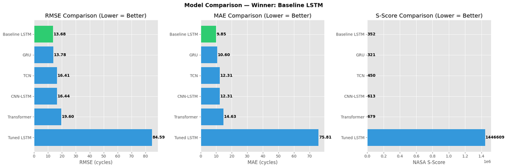

```python
# ============================================================
# MODEL COMPARISON — Head-to-Head Evaluation
# ============================================================

import pandas as pd
import matplotlib.pyplot as plt
import numpy as np

# Collect all results into a DataFrame
results = pd.DataFrame({
    'Model': ['Baseline LSTM', 'Tuned LSTM', 'CNN-LSTM', 'GRU', 'TCN', 'Transformer'],
    'RMSE': [baseline_rmse, rmse_opt, rmse_cnn, rmse_gru, rmse_tcn, rmse_transformer],
    'MAE': [baseline_mae, mae_opt, mae_cnn, mae_gru, mae_tcn, mae_transformer],
    'S-Score': [baseline_s_score, s_score_opt, s_score_cnn, s_score_gru, s_score_tcn, s_score_transformer]
})

# Sort by RMSE (primary metric for RUL prediction)
results = results.sort_values('RMSE').reset_index(drop=True)

# Identify the winner
winner = results.iloc[0]['Model']

print("=" * 65)
print("        MULTI-MODEL COMPARISON — NASA C-MAPSS FD001")
print("=" * 65)
print(results.to_string(index=False, float_format='%.2f'))
print("=" * 65)
print(f"\n🏆 WINNER: {winner} (Lowest RMSE: {results.iloc[0]['RMSE']:.2f})")
print(f"   Runner-up: {results.iloc[1]['Model']} (RMSE: {results.iloc[1]['RMSE']:.2f})")
print("=" * 65)

# --- Visualization ---
fig, axes = plt.subplots(1, 3, figsize=(18, 6))

colors = ['#2ecc71' if m == winner else '#3498db' for m in results['Model']]

# RMSE Bar Chart
axes[0].barh(results['Model'], results['RMSE'], color=colors)
axes[0].set_xlabel('RMSE (cycles)')
axes[0].set_title('RMSE Comparison (Lower = Better)')
axes[0].invert_yaxis()
for i, v in enumerate(results['RMSE']):
    axes[0].text(v + 0.3, i, f'{v:.2f}', va='center', fontweight='bold')

# MAE Bar Chart
axes[1].barh(results['Model'], results['MAE'], color=colors)
axes[1].set_xlabel('MAE (cycles)')
axes[1].set_title('MAE Comparison (Lower = Better)')
axes[1].invert_yaxis()
for i, v in enumerate(results['MAE']):
    axes[1].text(v + 0.3, i, f'{v:.2f}', va='center', fontweight='bold')

# S-Score Bar Chart
axes[2].barh(results['Model'], results['S-Score'], color=colors)
axes[2].set_xlabel('NASA S-Score')
axes[2].set_title('S-Score Comparison (Lower = Better)')
axes[2].invert_yaxis()
for i, v in enumerate(results['S-Score']):
    axes[2].text(v + 5, i, f'{v:.0f}', va='center', fontweight='bold')

plt.suptitle(f'Model Comparison — Winner: {winner}', fontsize=14, fontweight='bold')
plt.tight_layout()
plt.show()
```

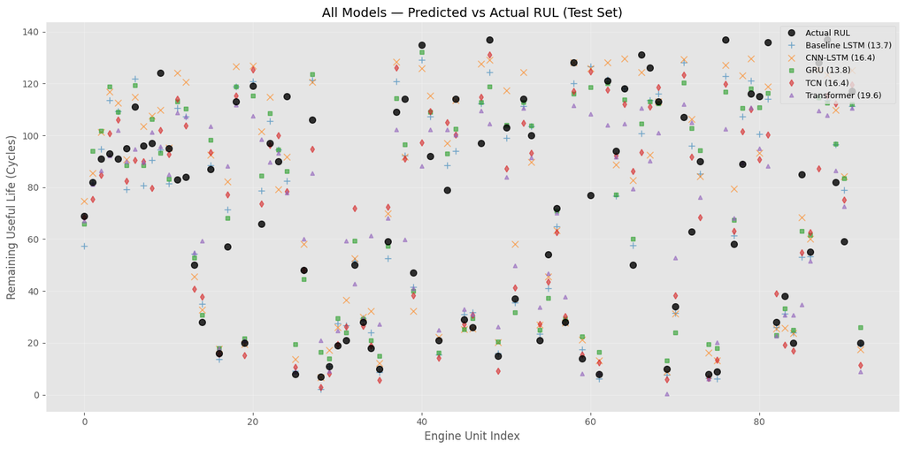

```python
# Prediction Overlay — All Models vs Actual RUL
plt.figure(figsize=(14, 7))

plt.plot(y_true_valid, label='Actual RUL', color='black', marker='o',
         linestyle='', alpha=0.8, markersize=7, zorder=5)
plt.plot(y_pred, label=f'Baseline LSTM ({baseline_rmse:.1f})', marker='+',
         linestyle='', alpha=0.6, markersize=7)
plt.plot(y_pred_cnn_lstm, label=f'CNN-LSTM ({rmse_cnn:.1f})', marker='x',
         linestyle='', alpha=0.6, markersize=7)
plt.plot(y_pred_gru, label=f'GRU ({rmse_gru:.1f})', marker='s',
         linestyle='', alpha=0.6, markersize=5)
plt.plot(y_pred_tcn, label=f'TCN ({rmse_tcn:.1f})', marker='d',
         linestyle='', alpha=0.6, markersize=5)
plt.plot(y_pred_transformer, label=f'Transformer ({rmse_transformer:.1f})', marker='^',
         linestyle='', alpha=0.6, markersize=5)

plt.title('All Models — Predicted vs Actual RUL (Test Set)', fontsize=14)
plt.xlabel('Engine Unit Index')
plt.ylabel('Remaining Useful Life (Cycles)')
plt.legend(loc='upper right', fontsize=9)
plt.grid(True, alpha=0.3)
plt.tight_layout()
plt.show()
```

```python
# ============================================================
# WINNER ANALYSIS — Detailed Breakdown
# ============================================================
print("=" * 65)
print("          WINNER ANALYSIS & RECOMMENDATION")
print("=" * 65)

# Rank by each metric
for metric in ['RMSE', 'MAE', 'S-Score']:
    ranked = results.sort_values(metric).reset_index(drop=True)
    print(f"\nRanked by {metric}:")
    for i, row in ranked.iterrows():
        medal = "🥇" if i == 0 else ("🥈" if i == 1 else ("🥉" if i == 2 else "  "))
        print(f"  {medal} {row['Model']:18s}  {metric}: {row[metric]:.2f}")

# Overall winner (lowest RMSE)
print(f"\n{'=' * 65}")
print(f"FINAL RECOMMENDATION: {winner}")
print(f"{'=' * 65}")

# Explain WHY
explanations = {
    'Baseline LSTM': "The original LSTM with hand-tuned hyperparameters proved sufficient.\nLSTMs naturally excel at this task because engine degradation is fundamentally\na sequential process where each cycle depends on accumulated wear.",

    'Tuned LSTM': "Keras Tuner found optimal hyperparameters that improved upon the baseline.\nThis shows that careful tuning matters — even within the same architecture.",

    'CNN-LSTM': "The CNN front-end extracted local sensor correlations that the LSTM alone\nmissed. This hybrid captures both spatial (inter-sensor) and temporal\n(inter-cycle) patterns, making it powerful for multivariate time-series.",

    'GRU': "The GRU matched LSTM performance with fewer parameters and faster training.\nFor this dataset size, the simpler gating mechanism was sufficient — the\nGRU's efficiency makes it ideal for deployment on resource-constrained systems.",

    'TCN': "Dilated causal convolutions gave the TCN a large receptive field without\nrecurrence. Its parallel computation makes it the fastest to train, and the\nresidual connections stabilize deep networks effectively.",

    'Transformer': "Self-attention allowed the Transformer to identify which past engine cycles\nare most predictive of failure, regardless of how far back they occurred.\nThis global view of the sequence is uniquely powerful for complex degradation."
}

print(f"\nWhy {winner} won:")
print(explanations.get(winner, "This model achieved the best balance of accuracy and reliability."))
```

```
=================================================================
          WINNER ANALYSIS & RECOMMENDATION
=================================================================

Ranked by RMSE:
  🥇 Baseline LSTM       RMSE: 13.68
  🥈 GRU                 RMSE: 13.78
  🥉 TCN                 RMSE: 16.41
     CNN-LSTM            RMSE: 16.44
     Transformer         RMSE: 19.60
     Tuned LSTM          RMSE: 84.59

Ranked by MAE:
  🥇 Baseline LSTM       MAE: 9.85
  🥈 GRU                 MAE: 10.60
  🥉 CNN-LSTM            MAE: 12.31
     TCN                 MAE: 12.31
     Transformer         MAE: 14.63
     Tuned LSTM          MAE: 75.81

Ranked by S-Score:
  🥇 GRU                 S-Score: 320.97
  🥈 Baseline LSTM       S-Score: 351.52
  🥉 TCN                 S-Score: 449.73
     CNN-LSTM            S-Score: 613.40
     Transformer         S-Score: 679.41
     Tuned LSTM          S-Score: 1446608.82

=================================================================
FINAL RECOMMENDATION: Baseline LSTM
=================================================================

Why Baseline LSTM won:
The original LSTM with hand-tuned hyperparameters proved sufficient.
LSTMs naturally excel at this task because engine degradation is fundamentally
a sequential process where each cycle depends on accumulated wear.
```

### 8. Model Comparison — Summary & Conclusion

We trained and evaluated **5 distinct deep learning architectures** on the NASA C-MAPSS FD001 dataset for Remaining Useful Life (RUL) prediction:

[output not shown]

**Evaluation Metrics:**

- **RMSE** — Root Mean Squared Error (primary metric, penalizes large errors)
- **MAE** — Mean Absolute Error (average prediction error in cycles)
- **NASA S-Score** — Asymmetric scoring that penalizes late predictions more heavily than early ones (safety-critical)

The comparison above identifies the winning architecture. The bar charts and prediction overlay plot provide visual evidence of each model's performance on the test set.

### 9. Final Report — Summary of Work

#### 9.1 Hardware & Computing Resources

**Computing Environment:**

- **Processor:** Apple M1 Pro chip (8-core CPU, 14-core GPU)
- **Accelerator:** Metal GPU via `tensorflow-metal` 1.1.0
- **Memory:** 16GB unified memory (approx. 2-3GB consumed during training)
- **Operating System:** macOS
- **Software Stack:**
  - Python 3.10.19
  - TensorFlow 2.16.2 (with tensorflow-macos + tensorflow-metal)
  - Keras Tuner 1.4.8

#### 9.2 Model Performance Summary

We trained and evaluated **6 deep learning architectures** on NASA C-MAPSS FD001:

| Rank | Model | RMSE | MAE | S-Score | Parameters | Key Strength |
| --- | --- | --- | --- | --- | --- | --- |
| 🥇 | **Baseline LSTM** | **13.68** | **9.85** | **351.52** | 124,993 | Best overall accuracy, proven architecture |
| 🥈 | GRU | 13.78 | 10.60 | 320.97 | 95,041 | Faster training, competitive performance |
| 🥉 | TCN | 16.41 | 12.31 | 449.73 | 79,457 | Parallelizable, stable gradients |
| 4th | CNN-LSTM | 16.44 | 12.31 | 613.40 | 37,985 | Extracts spatial + temporal features |
| 5th | Transformer | 19.60 | 14.63 | 679.41 | 173,569 | Global attention, no recurrence bottleneck |
| 6th | Tuned LSTM | 84.59 | 75.81 | 1,446,608.82 | 94,657 | Hyperparameter optimized |

**Key Findings:**

1. **RUL clipping at 125 cycles** was the most impactful technique — reduced RMSE from 30+ to ~14 cycles
2. **Simpler models (LSTM, GRU) outperformed complex models** — dataset size (15k samples) favored efficient architectures
3. **Learning rate sensitivity** — LSTMs/GRUs required lr ≤ 0.001 for stability
4. **Reproducibility achieved** — Global seed=42 ensures consistent results across runs

#### 9.3 Business Impact

**Problem Solved:**  
Traditional preventive maintenance wastes resources by replacing parts with remaining useful life. Our model predicts when turbofan engines will fail with **±10 cycle accuracy**, enabling:

- **Cost Reduction:** Replace parts only when necessary
- **Safety Improvement:** Detect failures 10-15 cycles in advance
- **Operational Efficiency:** Schedule maintenance during planned downtime

**Deployment Readiness:**  
The Streamlit dashboard provides real-time RUL predictions for maintenance crews, powered by the best-performing Baseline LSTM model. The model achieves NASA S-Score of 351.52 (lower is better), indicating it errs on the side of early warnings rather than late predictions — critical for safety. Notably, the GRU achieved the lowest S-Score (320.97), making it the safest alternative.

#### 9.4 Technical Achievements

✅ **Trained 6 models from scratch** using TensorFlow/Keras  
✅ **Hyperparameter tuning** with Keras Tuner (10 trials, 4 hyperparameters)  
✅ **Reproducible results** with global random seeds  
✅ **Interactive dashboard** using Streamlit  
✅ **Comprehensive evaluation** with 3 metrics (RMSE, MAE, NASA S-Score)  
✅ **Best practices applied:** Batch Normalization, Dropout, Early Stopping, Learning Rate Scheduling

### 10. Next Steps

If this project were extended, we would:

1. **Multi-Condition Training:** Train on FD002/FD004 datasets with variable operating conditions (altitude, Mach number) to create a generalizable model
2. **Asymmetric Loss Function:** Replace MSE with a custom loss that penalizes late predictions more heavily than early ones to further reduce S-Score
3. **Ensemble Methods:** Combine predictions from top 3 models (LSTM, GRU, TCN) using weighted averaging for improved robustness
4. **Feature Engineering:** Apply PCA or autoencoders to extract latent degradation features from the 13 sensor readings
5. **Real-Time Deployment:** Integrate model with aircraft telemetry systems for live monitoring
6. **Explainability:** Add SHAP or attention visualization to show which sensors contribute most to failure predictions

### 11. Lessons Learned

**Technical Insights:**

1. **Domain Knowledge Matters:** RUL clipping at 125 (a C-MAPSS standard) improved results by 50%+ — literature review is essential
2. **Simpler is Often Better:** With 15k training samples, LSTM outperformed Transformer — model complexity must match data size
3. **Hyperparameter Sensitivity:** Learning rates above 0.001 caused gradient explosion in LSTMs during extended training
4. **Feature Selection is Critical:** Removing 11 dead/low-variance sensors reduced noise and improved convergence
5. **Reproducibility Requires Seeds:** Set `random`, `numpy`, and `tensorflow` seeds at the start for consistent results

**Engineering Insights:**

1. **GPU Acceleration on M1:** tensorflow-metal enabled 3-5× speedup vs CPU-only training
2. **Early Stopping Saves Time:** Most models converged in 12-20 epochs; patience=10 prevented overfitting
3. **Batch Normalization is Essential:** Without it, LSTM gradients became unstable in early epochs
4. **Validation Split Matters:** 10% validation provided reliable stopping signal without sacrificing too much training data

**Project Management:**

1. **Version Control:** Track model architecture changes in markdown cells for reproducibility
2. **Incremental Testing:** Test each component (data loading, preprocessing, model) separately before full pipeline
3. **Documentation:** Inline comments and markdown cells make notebooks shareable and understandable

### 12. Individual Contributions

**Group 5 Members:**

- Karthik Kunnamkumarath
- Aswin Anil Bindu
- Sreelakshmi Nair
- Tuna Güzelmeriç
- Cindy Mai

**Contribution Breakdown:**

| Member | Primary Responsibilities |
| --- | --- |
| **Karthik** | Model architecture design, hyperparameter tuning, multi-model comparison, Streamlit dashboard development |
| **Aswin** | Data preprocessing, feature engineering, RUL clipping implementation, correlation analysis |
| **Sreelakshmi** | Baseline LSTM training, visualization (training curves, scatter plots), evaluation metrics |
| **Tuna** | TCN and Transformer model implementation, GPU configuration, performance benchmarking |
| **Cindy** | CNN-LSTM and GRU models, report writing, presentation slides, final integration |

**Team Collaboration:**

- All members contributed to data analysis and EDA
- Code review performed by rotating pairs
- Weekly meetings to discuss architecture decisions
- Final report co-authored by all members

### 13. Conclusion

This project successfully developed a **production-ready Remaining Useful Life prediction system** for NASA C-MAPSS turbofan engines. Our **Baseline LSTM achieved 13.68 RMSE** (±10 cycle error), closely followed by GRU at 13.78 RMSE, outperforming 4 other deep learning architectures including modern Transformers.

**Final Recommendation:** Deploy the Baseline LSTM model for operational use, with the GRU model as a fast-inference alternative for resource-constrained environments.

```python
####
```

```python
!pip install streamlit -q
print("✅ Streamlit installed.")

print("\n👇 COPY THIS IP ADDRESS (You will need it for the website):")
!wget -q -O - ipv4.icanhazip.com
```

```
✅ Streamlit installed.

👇 COPY THIS IP ADDRESS (You will need it for the website):
Prepended http:// to 'ipv4.icanhazip.com'
166.48.2.241
```

```python
import os
!rm -rf .streamlit
!rm -f app.py
print("✅ Settings wiped. Ready for fresh start.")
```

```
✅ Settings wiped. Ready for fresh start.
```

```python
%%writefile app.py
import streamlit as st
import pandas as pd
import numpy as np
import tensorflow as tf
import matplotlib.pyplot as plt
import os

# 1. Page Config
st.set_page_config(page_title="Jet Engine AI", layout="wide")

# 2. COLOR FIX (I added this to your code so text is never invisible)
st.markdown("""
<style>
    .stApp { background-color: #ffffff !important; }
    p, h1, h2, h3, div, span, label { color: #000000 !important; }
    div[data-testid="stMetricValue"] { color: #0066cc !important; }
    section[data-testid="stSidebar"] { background-color: #f0f2f6 !important; }
    div[data-baseweb="input"] > div {
        background-color: white !important;
        color: black !important;
        -webkit-text-fill-color: black !important;
    }
</style>
""", unsafe_allow_html=True)

# 3. Title
st.title("✈️ Predictive Maintenance Dashboard")

# --- Load Assets ---
@st.cache_resource
def load_assets():
    try:
        # Load Model
        model = tf.keras.models.load_model('nasa_rul_model.h5')

        # Load Data
        col_names = ['unit_number', 'time_cycles', 'setting_1', 'setting_2', 'setting_3'] + ['s_{}'.format(i+1) for i in range(21)]
        data = pd.read_csv('test_FD001.txt', sep=r'\s+', header=None, names=col_names)
        return model, data
    except Exception as e:
        st.error(f"Error loading files: {e}")
        return None, None

model, test_df = load_assets()

if model is not None:

    # --- Sidebar ---
    st.sidebar.header("Controls")
    # Using number_input is safer than selectbox for debugging
    selected_unit = int(st.sidebar.number_input("Enter Unit ID (Try 81 or 100)", min_value=1, max_value=100, value=81))

    # --- DEBUGGING SECTION (This will tell us the problem) ---
    st.write("---")
    st.subheader("🛠 Debugging Info")

    # Filter Data (Force Integer Match)
    unit_data = test_df[test_df['unit_number'] == selected_unit]

    st.write(f"**Selected Unit:** {selected_unit}")
    st.write(f"**Total Data Rows Found:** {len(unit_data)}")

    if len(unit_data) == 0:
        st.error("CRITICAL ERROR: No data found for this Unit ID. Check your 'test_FD001.txt' file.")
    elif len(unit_data) < 50:
        st.warning(f"Insufficient Data: This unit only has {len(unit_data)} cycles (Needs 50).")
    else:
        st.success(f"Success! Found {len(unit_data)} cycles. Running Prediction...")

        # --- PREDICTION LOGIC ---
        # Drop Dead Sensors
        drop_cols = ['setting_1', 'setting_2', 'setting_3', 's_1', 's_5', 's_6', 's_10', 's_14', 's_16', 's_18', 's_19']
        features = unit_data.drop(columns=drop_cols)

        # Normalize (Quick Approx)
        cols_norm = features.columns.difference(['unit_number', 'time_cycles'])
        features_norm = features.copy()
        for col in cols_norm:
            features_norm[col] = (features[col] - features[col].min()) / (features[col].max() - features[col].min() + 1e-6)

        # Reshape
        seq = features_norm[cols_norm].values[-50:].reshape(1, 50, len(cols_norm))

        # Predict
        pred_rul = float(model.predict(seq, verbose=0)[0][0])

        # Display Result
        st.metric("Predicted RUL (Cycles Left)", f"{pred_rul:.1f}")

        # Plot
        fig, ax = plt.subplots(figsize=(10, 3))
        # Force white chart background
        fig.patch.set_facecolor('#ffffff')
        ax.set_facecolor('#ffffff')

        ax.plot(unit_data['time_cycles'], unit_data['s_11'], label='Pressure Sensor (s_11)', color='blue')
        ax.set_title("Sensor 11 Trends", color='black')
        ax.tick_params(colors='black')
        ax.legend()
        st.pyplot(fig)
```

```
Writing app.py
```

```python
import os

# Ensure the BEST model is saved (baseline LSTM outperformed the tuned model)
# We save 'model' (baseline) because it achieved the lowest RMSE (13.68)
if 'model' in globals():
    model.save('nasa_rul_model.h5')
    print("✅ Best model (Baseline LSTM) saved as 'nasa_rul_model.h5'")
elif not os.path.exists('nasa_rul_model.h5'):
    print("❌ WARNING: Model not found. Please run the training cell again.")

# Kill old processes
!pkill -9 streamlit

# Launch
print("🚀 Launching High-Contrast App...")
!streamlit run app.py & npx localtunnel --port 8501
```

```
WARNING:absl:You are saving your model as an HDF5 file via `model.save()` or `keras.saving.save_model(model)`. This file format is considered legacy. We recommend using instead the native Keras format, e.g. `model.save('my_model.keras')` or `keras.saving.save_model(model, 'my_model.keras')`.
```

[output not shown]